# Data Transformation With dplyr

### 5.2 Add new variables with `mutate()`

- A tibble with fewer columns.

**R**

```r
flights_sml <-
  select(flights, year:day, ends_with("delay"), distance, air_time)
flights_sml
```

```
# A tibble: 336,776 × 7
    year month   day dep_delay arr_delay distance air_time
   <int> <int> <int>     <dbl>     <dbl>    <dbl>    <dbl>
 1  2013     1     1         2        11     1400      227
 2  2013     1     1         4        20     1416      227
 3  2013     1     1         2        33     1089      160
 4  2013     1     1        -1       -18     1576      183
 5  2013     1     1        -6       -25      762      116
 6  2013     1     1        -4        12      719      150
 7  2013     1     1        -5        19     1065      158
 8  2013     1     1        -3       -14      229       53
 9  2013     1     1        -3        -8      944      140
10  2013     1     1        -2         8      733      138
# ℹ 336,766 more rows
```

**Python (???)**

Is there better way?

```python
import re

cols = ['year', 'month', 'day'] + list(filter(re.compile(".*delay").match, flights.columns)) + ['distance', 'air_time']
flights_sml = flights.loc[:, cols]
flights_sml
```

```
        year  month  day  dep_delay  arr_delay  distance  air_time
0       2013      1    1        2.0       11.0      1400     227.0
1       2013      1    1        4.0       20.0      1416     227.0
2       2013      1    1        2.0       33.0      1089     160.0
3       2013      1    1       -1.0      -18.0      1576     183.0
4       2013      1    1       -6.0      -25.0       762     116.0
...      ...    ...  ...        ...        ...       ...       ...
336771  2013      9   30        NaN        NaN       213       NaN
336772  2013      9   30        NaN        NaN       198       NaN
336773  2013      9   30        NaN        NaN       764       NaN
336774  2013      9   30        NaN        NaN       419       NaN
336775  2013      9   30        NaN        NaN       431       NaN

[336776 rows x 7 columns]
```

**Julia**

```julia
flights_sml = select(flights, Between(:year, :day), r".*delay$", :distance, :air_time)
```

```
336776×7 DataFrame
    Row │ year   month  day    dep_delay  arr_delay  distance  air_time
        │ Int64  Int64  Int64  Float64?   Float64?   Float64   Float64?
────────┼────────────────────────────────────────────────────────────────
      1 │  2013      1      1        2.0       11.0    1400.0      227.0
      2 │  2013      1      1        4.0       20.0    1416.0      227.0
      3 │  2013      1      1        2.0       33.0    1089.0      160.0
      4 │  2013      1      1       -1.0      -18.0    1576.0      183.0
      5 │  2013      1      1       -6.0      -25.0     762.0      116.0
      6 │  2013      1      1       -4.0       12.0     719.0      150.0
      7 │  2013      1      1       -5.0       19.0    1065.0      158.0
      8 │  2013      1      1       -3.0      -14.0     229.0       53.0
   ⋮    │   ⋮      ⋮      ⋮        ⋮          ⋮         ⋮          ⋮
 336770 │  2013      9     30      -10.0      -25.0    1617.0      196.0
 336771 │  2013      9     30  missing    missing       764.0  missing
 336772 │  2013      9     30  missing    missing       213.0  missing
 336773 │  2013      9     30  missing    missing       198.0  missing
 336774 │  2013      9     30  missing    missing       764.0  missing
 336775 │  2013      9     30  missing    missing       419.0  missing
 336776 │  2013      9     30  missing    missing       431.0  missing
                                                      336761 rows omitted
```

```julia
flights_sml
```

```
336776×7 DataFrame
    Row │ year   month  day    dep_delay  arr_delay  distance  air_time
        │ Int64  Int64  Int64  Float64?   Float64?   Float64   Float64?
────────┼────────────────────────────────────────────────────────────────
      1 │  2013      1      1        2.0       11.0    1400.0      227.0
      2 │  2013      1      1        4.0       20.0    1416.0      227.0
      3 │  2013      1      1        2.0       33.0    1089.0      160.0
      4 │  2013      1      1       -1.0      -18.0    1576.0      183.0
      5 │  2013      1      1       -6.0      -25.0     762.0      116.0
      6 │  2013      1      1       -4.0       12.0     719.0      150.0
      7 │  2013      1      1       -5.0       19.0    1065.0      158.0
      8 │  2013      1      1       -3.0      -14.0     229.0       53.0
   ⋮    │   ⋮      ⋮      ⋮        ⋮          ⋮         ⋮          ⋮
 336770 │  2013      9     30      -10.0      -25.0    1617.0      196.0
 336771 │  2013      9     30  missing    missing       764.0  missing
 336772 │  2013      9     30  missing    missing       213.0  missing
 336773 │  2013      9     30  missing    missing       198.0  missing
 336774 │  2013      9     30  missing    missing       764.0  missing
 336775 │  2013      9     30  missing    missing       419.0  missing
 336776 │  2013      9     30  missing    missing       431.0  missing
                                                      336761 rows omitted
```

- Add variables `gain` and `speed`:

**R**

```r
mutate(
  flights_sml,
  gain = arr_delay - dep_delay,
  speed = distance / air_time * 60
)
```

```
# A tibble: 336,776 × 9
    year month   day dep_delay arr_delay distance air_time  gain speed
   <int> <int> <int>     <dbl>     <dbl>    <dbl>    <dbl> <dbl> <dbl>
 1  2013     1     1         2        11     1400      227     9  370.
 2  2013     1     1         4        20     1416      227    16  374.
 3  2013     1     1         2        33     1089      160    31  408.
 4  2013     1     1        -1       -18     1576      183   -17  517.
 5  2013     1     1        -6       -25      762      116   -19  394.
 6  2013     1     1        -4        12      719      150    16  288.
 7  2013     1     1        -5        19     1065      158    24  404.
 8  2013     1     1        -3       -14      229       53   -11  259.
 9  2013     1     1        -3        -8      944      140    -5  405.
10  2013     1     1        -2         8      733      138    10  319.
# ℹ 336,766 more rows
```

**Python**

```python
flights_sml['gain'] = flights_sml['arr_delay'] - flights_sml['dep_delay']
flights_sml['speed'] = flights_sml['distance'] / flights_sml['air_time'] * 60
flights_sml
```

```
        year  month  day  dep_delay  arr_delay  distance  air_time  gain  \
0       2013      1    1        2.0       11.0      1400     227.0   9.0
1       2013      1    1        4.0       20.0      1416     227.0  16.0
2       2013      1    1        2.0       33.0      1089     160.0  31.0
3       2013      1    1       -1.0      -18.0      1576     183.0 -17.0
4       2013      1    1       -6.0      -25.0       762     116.0 -19.0
...      ...    ...  ...        ...        ...       ...       ...   ...
336771  2013      9   30        NaN        NaN       213       NaN   NaN
336772  2013      9   30        NaN        NaN       198       NaN   NaN
336773  2013      9   30        NaN        NaN       764       NaN   NaN
336774  2013      9   30        NaN        NaN       419       NaN   NaN
336775  2013      9   30        NaN        NaN       431       NaN   NaN

             speed
0       370.044053
1       374.273128
2       408.375000
3       516.721311
4       394.137931
...            ...
336771         NaN
336772         NaN
336773         NaN
336774         NaN
336775         NaN

[336776 rows x 9 columns]
```

**Julia**

Julia analog is `transform`:

```julia
# Following are equivalent
transform(flights_sml, [:arr_delay, :dep_delay] => (-) => :gain)
```

```
336776×8 DataFrame
    Row │ year   month  day    dep_delay  arr_delay  distance  air_time   gain ⋯
        │ Int64  Int64  Int64  Float64?   Float64?   Float64   Float64?   Floa ⋯
────────┼───────────────────────────────────────────────────────────────────────
      1 │  2013      1      1        2.0       11.0    1400.0      227.0       ⋯
      2 │  2013      1      1        4.0       20.0    1416.0      227.0
      3 │  2013      1      1        2.0       33.0    1089.0      160.0
      4 │  2013      1      1       -1.0      -18.0    1576.0      183.0
      5 │  2013      1      1       -6.0      -25.0     762.0      116.0       ⋯
      6 │  2013      1      1       -4.0       12.0     719.0      150.0
      7 │  2013      1      1       -5.0       19.0    1065.0      158.0
      8 │  2013      1      1       -3.0      -14.0     229.0       53.0
   ⋮    │   ⋮      ⋮      ⋮        ⋮          ⋮         ⋮          ⋮           ⋱
 336770 │  2013      9     30      -10.0      -25.0    1617.0      196.0       ⋯
 336771 │  2013      9     30  missing    missing       764.0  missing    miss
 336772 │  2013      9     30  missing    missing       213.0  missing    miss
 336773 │  2013      9     30  missing    missing       198.0  missing    miss
 336774 │  2013      9     30  missing    missing       764.0  missing    miss ⋯
 336775 │  2013      9     30  missing    missing       419.0  missing    miss
 336776 │  2013      9     30  missing    missing       431.0  missing    miss
                                                1 column and 336761 rows omitted
```

```julia
insertcols!(flights_sml, :gain => flights.arr_delay - flights.dep_delay)
```

```
336776×8 DataFrame
    Row │ year   month  day    dep_delay  arr_delay  distance  air_time   gain ⋯
        │ Int64  Int64  Int64  Float64?   Float64?   Float64   Float64?   Floa ⋯
────────┼───────────────────────────────────────────────────────────────────────
      1 │  2013      1      1        2.0       11.0    1400.0      227.0       ⋯
      2 │  2013      1      1        4.0       20.0    1416.0      227.0
      3 │  2013      1      1        2.0       33.0    1089.0      160.0
      4 │  2013      1      1       -1.0      -18.0    1576.0      183.0
      5 │  2013      1      1       -6.0      -25.0     762.0      116.0       ⋯
      6 │  2013      1      1       -4.0       12.0     719.0      150.0
      7 │  2013      1      1       -5.0       19.0    1065.0      158.0
      8 │  2013      1      1       -3.0      -14.0     229.0       53.0
   ⋮    │   ⋮      ⋮      ⋮        ⋮          ⋮         ⋮          ⋮           ⋱
 336770 │  2013      9     30      -10.0      -25.0    1617.0      196.0       ⋯
 336771 │  2013      9     30  missing    missing       764.0  missing    miss
 336772 │  2013      9     30  missing    missing       213.0  missing    miss
 336773 │  2013      9     30  missing    missing       198.0  missing    miss
 336774 │  2013      9     30  missing    missing       764.0  missing    miss ⋯
 336775 │  2013      9     30  missing    missing       419.0  missing    miss
 336776 │  2013      9     30  missing    missing       431.0  missing    miss
                                                1 column and 336761 rows omitted
```

- Refer to columns that you’ve just created:

**R**

```r
mutate(flights_sml,
       gain = arr_delay - dep_delay,
       hours = air_time / 60,
       gain_per_hour = gain / hours
)
```

```
# A tibble: 336,776 × 10
    year month   day dep_delay arr_delay distance air_time  gain hours
   <int> <int> <int>     <dbl>     <dbl>    <dbl>    <dbl> <dbl> <dbl>
 1  2013     1     1         2        11     1400      227     9 3.78
 2  2013     1     1         4        20     1416      227    16 3.78
 3  2013     1     1         2        33     1089      160    31 2.67
 4  2013     1     1        -1       -18     1576      183   -17 3.05
 5  2013     1     1        -6       -25      762      116   -19 1.93
 6  2013     1     1        -4        12      719      150    16 2.5
 7  2013     1     1        -5        19     1065      158    24 2.63
 8  2013     1     1        -3       -14      229       53   -11 0.883
 9  2013     1     1        -3        -8      944      140    -5 2.33
10  2013     1     1        -2         8      733      138    10 2.3
# ℹ 336,766 more rows
# ℹ 1 more variable: gain_per_hour <dbl>
```

**Python (???)**

Not sure how to refer to columns in the same command.

**Julia (???)**

Not sure how to do this, except using two lines.

```julia
# Following are equivalent
@pipe flights |>
  transform(
    _ ,
    [:arr_delay, :dep_delay] => (-) => :gain,
    [:air_time] => (x -> x / 60)  => :hours,
  ) |>
  transform(
    _,
    [:gain, :hours] => ByRow(/) => :gain_per_hour
  )
```

```
336776×22 DataFrame
    Row │ year   month  day    dep_time  sched_dep_time  dep_delay  arr_time   ⋯
        │ Int64  Int64  Int64  Int64?    Int64           Float64?   Int64?     ⋯
────────┼───────────────────────────────────────────────────────────────────────
      1 │  2013      1      1       517             515        2.0       830   ⋯
      2 │  2013      1      1       533             529        4.0       850
      3 │  2013      1      1       542             540        2.0       923
      4 │  2013      1      1       544             545       -1.0      1004
      5 │  2013      1      1       554             600       -6.0       812   ⋯
      6 │  2013      1      1       554             558       -4.0       740
      7 │  2013      1      1       555             600       -5.0       913
      8 │  2013      1      1       557             600       -3.0       709
   ⋮    │   ⋮      ⋮      ⋮       ⋮            ⋮             ⋮         ⋮       ⋱
 336770 │  2013      9     30      2349            2359      -10.0       325   ⋯
 336771 │  2013      9     30   missing            1842  missing     missing
 336772 │  2013      9     30   missing            1455  missing     missing
 336773 │  2013      9     30   missing            2200  missing     missing
 336774 │  2013      9     30   missing            1210  missing     missing   ⋯
 336775 │  2013      9     30   missing            1159  missing     missing
 336776 │  2013      9     30   missing             840  missing     missing
                                              15 columns and 336761 rows omitted
```

- Only keep the new variables by `transmute()`:

```r
transmute(
  flights,
  gain = arr_delay - dep_delay,
  hours = air_time / 60,
  gain_per_hour = gain / hours
)
```

```
# A tibble: 336,776 × 3
    gain hours gain_per_hour
   <dbl> <dbl>         <dbl>
 1     9 3.78           2.38
 2    16 3.78           4.23
 3    31 2.67          11.6
 4   -17 3.05          -5.57
 5   -19 1.93          -9.83
 6    16 2.5            6.4
 7    24 2.63           9.11
 8   -11 0.883        -12.5
 9    -5 2.33          -2.14
10    10 2.3            4.35
# ℹ 336,766 more rows
```

- `mutate_all()`: apply funs to all columns.

**R**

```r
mutate_all(data, funs(log(.), log2(.)))
```

**Python (???)**

TODO

**Julia**

```julia
mapcols(col -> 2col, df)
```

- `mutate_at()`: apply funs to specific columns.

```r
mutate_at(data, vars(-Species), funs(log(.)))
```

- `mutate_if()`: apply funs of one type

```r
mutate_if(data, is.numeric, funs(log(.)))
```

## 6 Summaries

### 6.1 Summaries with `summarise()`

- Mean of a variable:

**R**

```r
summarise(flights, delay = mean(dep_delay, na.rm = TRUE))
```

```
# A tibble: 1 × 1
  delay
  <dbl>
1  12.6
```

**Python**

```python
flights.agg({'dep_delay': np.mean})
```

```
dep_delay    12.63907
dtype: float64
```

**Julia**

```julia
combine(flights, :dep_delay => (x -> mean(skipmissing(x))) => :delay)
```

```
1×1 DataFrame
 Row │ delay
     │ Float64
─────┼─────────
   1 │ 12.6391
```

- Convert a tibble into a grouped tibble:

**R**

```r
by_day <- group_by(flights, year, month, day) |>
  print(width = Inf)
```

```
# A tibble: 336,776 × 19
# Groups:   year, month, day [365]
    year month   day dep_time sched_dep_time dep_delay arr_time sched_arr_time
   <int> <int> <int>    <int>          <int>     <dbl>    <int>          <int>
 1  2013     1     1      517            515         2      830            819
 2  2013     1     1      533            529         4      850            830
 3  2013     1     1      542            540         2      923            850
 4  2013     1     1      544            545        -1     1004           1022
 5  2013     1     1      554            600        -6      812            837
 6  2013     1     1      554            558        -4      740            728
 7  2013     1     1      555            600        -5      913            854
 8  2013     1     1      557            600        -3      709            723
 9  2013     1     1      557            600        -3      838            846
10  2013     1     1      558            600        -2      753            745
   arr_delay carrier flight tailnum origin dest  air_time distance  hour minute
```

[output cut: 24 more lines]

**Python**

```python
by_day = flights.groupby(['year', 'month', 'day'])
by_day
```

```
<pandas.core.groupby.generic.DataFrameGroupBy object at 0xffff318000a0>
```

**Julia**

```julia
by_day = groupby(flights, [:year, :month, :day])
```

```
GroupedDataFrame with 365 groups based on keys: year, month, day
First Group (842 rows): year = 2013, month = 1, day = 1
 Row │ year   month  day    dep_time  sched_dep_time  dep_delay  arr_time  sch ⋯
     │ Int64  Int64  Int64  Int64?    Int64           Float64?   Int64?    Int ⋯
─────┼──────────────────────────────────────────────────────────────────────────
   1 │  2013      1      1       517             515        2.0       830      ⋯
   2 │  2013      1      1       533             529        4.0       850
  ⋮  │   ⋮      ⋮      ⋮       ⋮            ⋮             ⋮         ⋮          ⋱
 841 │  2013      1      1   missing            1500  missing     missing
 842 │  2013      1      1   missing             600  missing     missing
                                                 12 columns and 838 rows omitted
⋮
Last Group (776 rows): year = 2013, month = 12, day = 31
 Row │ year   month  day    dep_time  sched_dep_time  dep_delay  arr_time  sch ⋯
     │ Int64  Int64  Int64  Int64?    Int64           Float64?   Int64?    Int ⋯
─────┼──────────────────────────────────────────────────────────────────────────
   1 │  2013     12     31        13            2359       14.0       439      ⋯
   2 │  2013     12     31        18            2359       19.0       449
  ⋮  │   ⋮      ⋮      ⋮       ⋮            ⋮             ⋮         ⋮          ⋱
 776 │  2013     12     31   missing             830  missing     missing
                                                 12 columns and 773 rows omitted
```

```julia
by_day
```

```
GroupedDataFrame with 365 groups based on keys: year, month, day
First Group (842 rows): year = 2013, month = 1, day = 1
 Row │ year   month  day    dep_time  sched_dep_time  dep_delay  arr_time  sch ⋯
     │ Int64  Int64  Int64  Int64?    Int64           Float64?   Int64?    Int ⋯
─────┼──────────────────────────────────────────────────────────────────────────
   1 │  2013      1      1       517             515        2.0       830      ⋯
   2 │  2013      1      1       533             529        4.0       850
  ⋮  │   ⋮      ⋮      ⋮       ⋮            ⋮             ⋮         ⋮          ⋱
 841 │  2013      1      1   missing            1500  missing     missing
 842 │  2013      1      1   missing             600  missing     missing
                                                 12 columns and 838 rows omitted
⋮
Last Group (776 rows): year = 2013, month = 12, day = 31
 Row │ year   month  day    dep_time  sched_dep_time  dep_delay  arr_time  sch ⋯
     │ Int64  Int64  Int64  Int64?    Int64           Float64?   Int64?    Int ⋯
─────┼──────────────────────────────────────────────────────────────────────────
   1 │  2013     12     31        13            2359       14.0       439      ⋯
   2 │  2013     12     31        18            2359       19.0       449
  ⋮  │   ⋮      ⋮      ⋮       ⋮            ⋮             ⋮         ⋮          ⋱
 776 │  2013     12     31   missing             830  missing     missing
                                                 12 columns and 773 rows omitted
```

- Grouped summaries:

```r
summarise(by_day, delay = mean(dep_delay, na.rm = TRUE))
```

```
# A tibble: 365 × 4
# Groups:   year, month [12]
    year month   day delay
   <int> <int> <int> <dbl>
 1  2013     1     1 11.5
 2  2013     1     2 13.9
 3  2013     1     3 11.0
 4  2013     1     4  8.95
 5  2013     1     5  5.73
 6  2013     1     6  7.15
 7  2013     1     7  5.42
 8  2013     1     8  2.55
 9  2013     1     9  2.28
10  2013     1    10  2.84
# ℹ 355 more rows
```

### 6.2 Pipe

- Consider following analysis (find destinations excluding `HNL` that have >20 flights, and calculate the average distances and arrival delay):

```r
by_dest <- group_by(flights, dest)
delay <- summarise(by_dest, count = n(),
                   dist = mean(distance, na.rm = TRUE),
                   delay = mean(arr_delay, na.rm = TRUE)
)
delay <- filter(delay, count > 20, dest != "HNL")
delay
```

```
# A tibble: 96 × 4
   dest  count  dist delay
   <chr> <int> <dbl> <dbl>
 1 ABQ     254 1826   4.38
 2 ACK     265  199   4.85
 3 ALB     439  143  14.4
 4 ATL   17215  757. 11.3
 5 AUS    2439 1514.  6.02
 6 AVL     275  584.  8.00
 7 BDL     443  116   7.05
 8 BGR     375  378   8.03
 9 BHM     297  866. 16.9
10 BNA    6333  758. 11.8
# ℹ 86 more rows
```

- Cleaner code using pipe `|>`:

```r
delays <- flights |>
  group_by(dest) |>
  summarise(
    count = n(),
    dist = mean(distance, na.rm = TRUE),
    delay = mean(arr_delay, na.rm = TRUE)
  ) |>
  filter(count > 20, dest != "HNL")
delays
```

```
# A tibble: 96 × 4
   dest  count  dist delay
   <chr> <int> <dbl> <dbl>
 1 ABQ     254 1826   4.38
 2 ACK     265  199   4.85
 3 ALB     439  143  14.4
 4 ATL   17215  757. 11.3
 5 AUS    2439 1514.  6.02
 6 AVL     275  584.  8.00
 7 BDL     443  116   7.05
 8 BGR     375  378   8.03
 9 BHM     297  866. 16.9
10 BNA    6333  758. 11.8
# ℹ 86 more rows
```

- ggplot2 accepts pipe too.

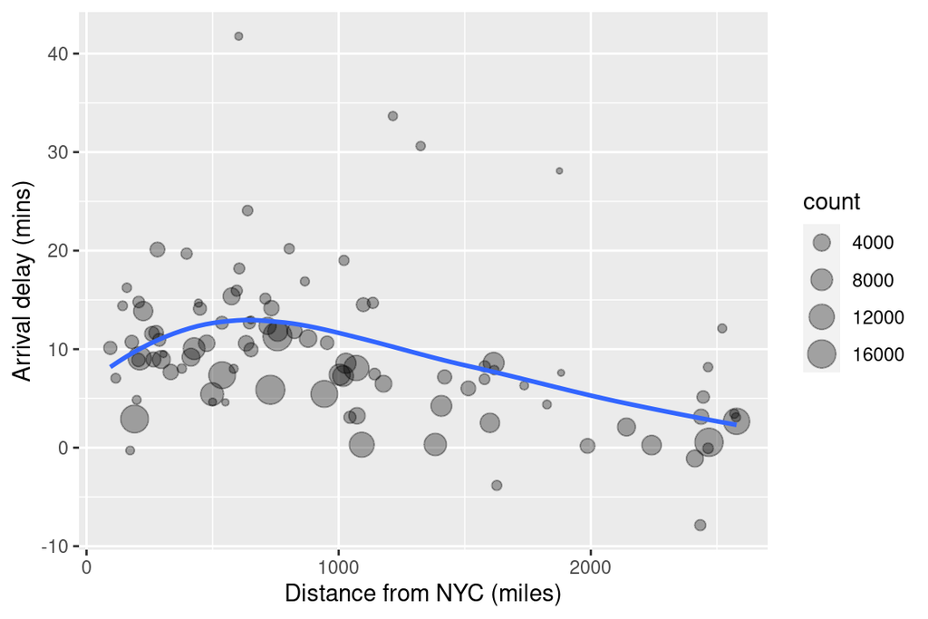

```r
delays |>
  ggplot(mapping = aes(x = dist, y = delay)) +
  geom_point(aes(size = count), alpha = 1/3) +
  geom_smooth(se = FALSE) +
  labs(x = "Distance from NYC (miles)",
       y = "Arrival delay (mins)")
```

### 6.3 Other summary functions

- Location: `mean(x)`, `median(x)`.

**R**

```r
# Equivalent code using filter
# not_cancelled <- flights |>
#   filter(!is.na(dep_delay), !is.na(arr_delay)) |>
#   print(width = Inf)
not_cancelled <- flights |>
  drop_na(dep_delay, arr_delay) |>
  print(width = Inf)
```

```
# A tibble: 327,346 × 19
    year month   day dep_time sched_dep_time dep_delay arr_time sched_arr_time
   <int> <int> <int>    <int>          <int>     <dbl>    <int>          <int>
 1  2013     1     1      517            515         2      830            819
 2  2013     1     1      533            529         4      850            830
 3  2013     1     1      542            540         2      923            850
 4  2013     1     1      544            545        -1     1004           1022
 5  2013     1     1      554            600        -6      812            837
 6  2013     1     1      554            558        -4      740            728
 7  2013     1     1      555            600        -5      913            854
 8  2013     1     1      557            600        -3      709            723
 9  2013     1     1      557            600        -3      838            846
10  2013     1     1      558            600        -2      753            745
   arr_delay carrier flight tailnum origin dest  air_time distance  hour minute
       <dbl> <chr>    <int> <chr>   <chr>  <chr>    <dbl>    <dbl> <dbl>  <dbl>
```

[output cut: 23 more lines]

```r
not_cancelled |>
  group_by(year, month, day) |>
  summarise(
    avg_delay1 = mean(arr_delay),
    avg_delay2 = mean(arr_delay[arr_delay > 0]), # the average positive delay
  )
```

```
# A tibble: 365 × 5
# Groups:   year, month [12]
    year month   day avg_delay1 avg_delay2
   <int> <int> <int>      <dbl>      <dbl>
 1  2013     1     1     12.7         32.5
 2  2013     1     2     12.7         32.0
 3  2013     1     3      5.73        27.7
 4  2013     1     4     -1.93        28.3
 5  2013     1     5     -1.53        22.6
 6  2013     1     6      4.24        24.4
 7  2013     1     7     -4.95        27.8
 8  2013     1     8     -3.23        20.8
 9  2013     1     9     -0.264       25.6
10  2013     1    10     -5.90        27.3
# ℹ 355 more rows
```

Question: why is the `day` group dropped?

**Python**

```python
not_cancelled = flights.dropna(subset = ['dep_delay', 'arr_delay'])
not_cancelled
```

```
        year  month  day  dep_time  sched_dep_time  dep_delay  arr_time  \
0       2013      1    1     517.0             515        2.0     830.0
1       2013      1    1     533.0             529        4.0     850.0
2       2013      1    1     542.0             540        2.0     923.0
3       2013      1    1     544.0             545       -1.0    1004.0
4       2013      1    1     554.0             600       -6.0     812.0
...      ...    ...  ...       ...             ...        ...       ...
336765  2013      9   30    2240.0            2245       -5.0    2334.0
336766  2013      9   30    2240.0            2250      -10.0    2347.0
336767  2013      9   30    2241.0            2246       -5.0    2345.0
336768  2013      9   30    2307.0            2255       12.0    2359.0
336769  2013      9   30    2349.0            2359      -10.0     325.0

        sched_arr_time  arr_delay carrier  flight tailnum origin dest  \
0                  819       11.0      UA    1545  N14228    EWR  IAH
```

[output cut: 25 more lines]

```python
flights.groupby(['year', 'month', 'day']).agg(
  avg_delay1 = ('arr_delay', np.mean),
  avg_delay2 = ('arr_delay', lambda x: np.mean(x[x > 0]))
)
```

```
                avg_delay1  avg_delay2
year month day
2013 1     1     12.651023   32.481562
           2     12.692888   32.029907
           3      5.733333   27.660870
           4     -1.932819   28.309764
           5     -1.525802   22.558824
           6      4.236429   24.372703
           7     -4.947312   27.761317
           8     -3.227578   20.789091
           9     -0.264278   25.634146
           10    -5.898816   27.345455
           11    -4.762268   26.159836
           12   -13.016153   23.471698
           13    14.931846   52.548913
```

[output cut: 352 more lines]

**Julia**

```julia
not_cancelled = dropmissing(flights, [:dep_delay, :arr_delay])
```

```
327346×19 DataFrame
    Row │ year   month  day    dep_time  sched_dep_time  dep_delay  arr_time   ⋯
        │ Int64  Int64  Int64  Int64?    Int64           Float64    Int64?     ⋯
────────┼───────────────────────────────────────────────────────────────────────
      1 │  2013      1      1       517             515        2.0       830   ⋯
      2 │  2013      1      1       533             529        4.0       850
      3 │  2013      1      1       542             540        2.0       923
      4 │  2013      1      1       544             545       -1.0      1004
      5 │  2013      1      1       554             600       -6.0       812   ⋯
      6 │  2013      1      1       554             558       -4.0       740
      7 │  2013      1      1       555             600       -5.0       913
      8 │  2013      1      1       557             600       -3.0       709
   ⋮    │   ⋮      ⋮      ⋮       ⋮            ⋮             ⋮         ⋮       ⋱
 327340 │  2013      9     30      2235            2001      154.0        59   ⋯
 327341 │  2013      9     30      2237            2245       -8.0      2345
 327342 │  2013      9     30      2240            2245       -5.0      2334
 327343 │  2013      9     30      2240            2250      -10.0      2347
 327344 │  2013      9     30      2241            2246       -5.0      2345   ⋯
 327345 │  2013      9     30      2307            2255       12.0      2359
 327346 │  2013      9     30      2349            2359      -10.0       325
                                              12 columns and 327331 rows omitted
```

```julia
not_cancelled
```

```
327346×19 DataFrame
    Row │ year   month  day    dep_time  sched_dep_time  dep_delay  arr_time   ⋯
        │ Int64  Int64  Int64  Int64?    Int64           Float64    Int64?     ⋯
────────┼───────────────────────────────────────────────────────────────────────
      1 │  2013      1      1       517             515        2.0       830   ⋯
      2 │  2013      1      1       533             529        4.0       850
      3 │  2013      1      1       542             540        2.0       923
      4 │  2013      1      1       544             545       -1.0      1004
      5 │  2013      1      1       554             600       -6.0       812   ⋯
      6 │  2013      1      1       554             558       -4.0       740
      7 │  2013      1      1       555             600       -5.0       913
      8 │  2013      1      1       557             600       -3.0       709
   ⋮    │   ⋮      ⋮      ⋮       ⋮            ⋮             ⋮         ⋮       ⋱
 327340 │  2013      9     30      2235            2001      154.0        59   ⋯
 327341 │  2013      9     30      2237            2245       -8.0      2345
 327342 │  2013      9     30      2240            2245       -5.0      2334
 327343 │  2013      9     30      2240            2250      -10.0      2347
 327344 │  2013      9     30      2241            2246       -5.0      2345   ⋯
 327345 │  2013      9     30      2307            2255       12.0      2359
 327346 │  2013      9     30      2349            2359      -10.0       325
                                              12 columns and 327331 rows omitted
```

```julia
@pipe not_cancelled |>
  groupby(_, [:year, :month, :day]) |>
  combine(
    _,
    :arr_delay => (x -> [(mean(x), mean(skipmissing(x[x .>= 0])))]) => [:avg_delay1, :avg_delay2]
    )
```

```
365×5 DataFrame
 Row │ year   month  day    avg_delay1  avg_delay2
     │ Int64  Int64  Int64  Float64     Float64
─────┼─────────────────────────────────────────────
   1 │  2013      1      1   12.651        31.5907
   2 │  2013      1      2   12.6929       30.9314
   3 │  2013      1      3    5.73333      26.2351
   4 │  2013      1      4   -1.93282      27.1226
   5 │  2013      1      5   -1.5258       20.9727
   6 │  2013      1      6    4.23643      22.9284
   7 │  2013      1      7   -4.94731      25.8467
   8 │  2013      1      8   -3.22758      19.5788
  ⋮  │   ⋮      ⋮      ⋮        ⋮           ⋮
 359 │  2013     12     25   -1.8993       29.0773
 360 │  2013     12     26    7.17419      33.0568
 361 │  2013     12     27   -0.148803     27.1054
 362 │  2013     12     28   -3.25953      24.4779
 363 │  2013     12     29   18.7638       46.5658
 364 │  2013     12     30   10.0577       29.4776
 365 │  2013     12     31    6.21212      23.1941
                                   350 rows omitted
```

- Spread: `sd(x)`, `IQR(x)`, `mad(x)`.

**R**

```r
# destinations with largest variation in distance
not_cancelled |>
  group_by(dest) |>
  summarise(distance_sd = sd(distance)) |>
  arrange(desc(distance_sd))
```

```
# A tibble: 104 × 2
   dest  distance_sd
   <chr>       <dbl>
 1 EGE         10.5
 2 SAN         10.4
 3 SFO         10.2
 4 HNL         10.0
 5 SEA          9.98
 6 LAS          9.91
 7 PDX          9.87
 8 PHX          9.86
 9 LAX          9.66
10 IND          9.46
# ℹ 94 more rows
```

**Python**

```python
flights.groupby(['dest']).agg(
  distance_sd = ('distance', np.std)
).sort_values('distance_sd', ascending = False)
```

```
      distance_sd
dest
EGE     10.549066
SAN     10.346588
SFO     10.216858
HNL     10.001783
SEA      9.979116
LAS      9.913856
PDX      9.880313
PHX      9.856062
LAX      9.657222
IND      9.455668
SAT      9.000096
CVG      8.992937
MEM      8.497715
HOU      8.476723
MCI      8.387283
AUS      8.318982
DFW      8.305072
CLE      8.282101
TYS      8.004084
IAH      8.001671
DEN      7.981494
STL      7.899533
BNA      7.814711
ORD      7.731902
PIT      7.731472
BUF      7.724076
DTW      7.581811
ROC      7.452263
SDF      7.367790
SLC      7.363589
GSO      7.352531
MSP      7.296561
SBN      7.229569
XNA      7.194400
ATL      7.155615
MSY      7.088342
CMH      7.071074
MDW      7.000700
```

[output cut: 52 more lines]

```
ILM      0.000000
LGB      0.000000
ACK      0.000000
CHO      0.000000
MTJ      0.000000
PSP      0.000000
MVY      0.000000
OAK      0.000000
OKC      0.000000
BZN      0.000000
BUR      0.000000
PSE      0.000000
ABQ      0.000000
LEX           NaN
LGA           NaN
```

**Julia**

```julia
@pipe flights |>
  groupby(_, :dest) |>
  combine(_, :distance => std => :distance_sd) |>
  sort(_, :distance_sd, rev = true)
```

```
105×2 DataFrame
 Row │ dest    distance_sd
     │ String  Float64
─────┼─────────────────────
   1 │ LEX       NaN
   2 │ LGA       NaN
   3 │ EGE        10.5491
   4 │ SAN        10.3466
   5 │ SFO        10.2169
   6 │ HNL        10.0018
   7 │ SEA         9.97912
   8 │ LAS         9.91386
  ⋮  │   ⋮          ⋮
  99 │ ACK         0.0
 100 │ BGR         0.0
 101 │ ABQ         0.0
 102 │ ILM         0.0
 103 │ MVY         0.0
 104 │ CHO         0.0
 105 │ ANC         0.0
            90 rows omitted
```

- Rank: `min(x)`, `quantile(x, 0.25)`, `max(x)`.

**R**

```r
# Earliest and latest flights on each day?
not_cancelled |>
  group_by(year, month, day) |>
  summarise(
    first = min(dep_time),
    last = max(dep_time)
  )
```

```
# A tibble: 365 × 5
# Groups:   year, month [12]
    year month   day first  last
   <int> <int> <int> <int> <int>
 1  2013     1     1   517  2356
 2  2013     1     2    42  2354
 3  2013     1     3    32  2349
 4  2013     1     4    25  2358
 5  2013     1     5    14  2357
 6  2013     1     6    16  2355
 7  2013     1     7    49  2359
 8  2013     1     8   454  2351
 9  2013     1     9     2  2252
10  2013     1    10     3  2320
# ℹ 355 more rows
```

**Python**

```python
not_cancelled.groupby(['year', 'month', 'day']).agg(
  first = ('dep_time', np.min),
  last = ('dep_time', np.max)
)
```

```
                first    last
year month day
2013 1     1    517.0  2356.0
           2     42.0  2354.0
           3     32.0  2349.0
           4     25.0  2358.0
           5     14.0  2357.0
           6     16.0  2355.0
           7     49.0  2359.0
           8    454.0  2351.0
           9      2.0  2252.0
           10     3.0  2320.0
           11    11.0  2304.0
           12    30.0  2359.0
           13     1.0  2359.0
```

[output cut: 352 more lines]

**Julia**

```julia
@pipe not_cancelled |>
  groupby(_, [:year, :month, :day]) |>
  combine(_, :dep_time => (x -> [extrema(x)]) => [:first, :last])
```

```
365×5 DataFrame
 Row │ year   month  day    first  last
     │ Int64  Int64  Int64  Int64  Int64
─────┼───────────────────────────────────
   1 │  2013      1      1    517   2356
   2 │  2013      1      2     42   2354
   3 │  2013      1      3     32   2349
   4 │  2013      1      4     25   2358
   5 │  2013      1      5     14   2357
   6 │  2013      1      6     16   2355
   7 │  2013      1      7     49   2359
   8 │  2013      1      8    454   2351
  ⋮  │   ⋮      ⋮      ⋮      ⋮      ⋮
 359 │  2013     12     25    456   2357
 360 │  2013     12     26      1   2355
 361 │  2013     12     27      2   2351
 362 │  2013     12     28      7   2358
 363 │  2013     12     29      3   2400
 364 │  2013     12     30      1   2356
 365 │  2013     12     31     13   2356
                         350 rows omitted
```

- Position: `first(x)`, `nth(x, 2)`, `last(x)`. Note unless the variable is sorted, `first` is different from `min` and `last` is different from `max`.

**R**

```r
not_cancelled |>
  group_by(year, month, day) |>
  summarise(
    first_dep = first(dep_time),
    last_dep = last(dep_time)
  )
```

```
# A tibble: 365 × 5
# Groups:   year, month [12]
    year month   day first_dep last_dep
   <int> <int> <int>     <int>    <int>
 1  2013     1     1       517     2356
 2  2013     1     2        42     2354
 3  2013     1     3        32     2349
 4  2013     1     4        25     2358
 5  2013     1     5        14     2357
 6  2013     1     6        16     2355
 7  2013     1     7        49     2359
 8  2013     1     8       454     2351
 9  2013     1     9         2     2252
10  2013     1    10         3     2320
# ℹ 355 more rows
```

**Python**

```python
not_cancelled.groupby(['year', 'month', 'day']).agg(
  first_dep = ('dep_time', lambda x: x.iloc[0]),
  last_dep = ('dep_time', lambda x: x.iloc[-1]),
)
```

```
                first_dep  last_dep
year month day
2013 1     1        517.0    2356.0
           2         42.0    2354.0
           3         32.0    2349.0
           4         25.0    2358.0
           5         14.0    2357.0
           6         16.0    2355.0
           7         49.0    2359.0
           8        454.0    2351.0
           9          2.0    2252.0
           10         3.0    2320.0
           11        11.0    2304.0
           12        30.0    2359.0
           13         1.0    2359.0
```

[output cut: 352 more lines]

**Julia**

```julia
@pipe not_cancelled |>
  groupby(_, [:year, :month, :day]) |>
  combine(
    _,
    :dep_time => first => :first_dep,
    :dep_time => last => :last_dep
    )
```

```
365×5 DataFrame
 Row │ year   month  day    first_dep  last_dep
     │ Int64  Int64  Int64  Int64      Int64
─────┼──────────────────────────────────────────
   1 │  2013      1      1        517      2356
   2 │  2013      1      2         42      2354
   3 │  2013      1      3         32      2349
   4 │  2013      1      4         25      2358
   5 │  2013      1      5         14      2357
   6 │  2013      1      6         16      2355
   7 │  2013      1      7         49      2359
   8 │  2013      1      8        454      2351
  ⋮  │   ⋮      ⋮      ⋮        ⋮         ⋮
 359 │  2013     12     25        456      2357
 360 │  2013     12     26          1      2355
 361 │  2013     12     27          2      2351
 362 │  2013     12     28          7      2358
 363 │  2013     12     29          3      2400
 364 │  2013     12     30          1      2356
 365 │  2013     12     31         13      2356
                                350 rows omitted
```

- Count: `n(x)`, `sum(!is.na(x))`, `n_distinct(x)`.

**R**

```r
# Which destinations have the most carriers?
not_cancelled |>
  group_by(dest) |>
  summarise(carriers = n_distinct(carrier)) |>
  arrange(desc(carriers))
```

```
# A tibble: 104 × 2
   dest  carriers
   <chr>    <int>
 1 ATL          7
 2 BOS          7
 3 CLT          7
 4 ORD          7
 5 TPA          7
 6 AUS          6
 7 DCA          6
 8 DTW          6
 9 IAD          6
10 MSP          6
# ℹ 94 more rows
```

Similarly

```r
# which destination has most flights from NYC?
not_cancelled |>
  count(dest) |>
  arrange(desc(n))
```

```
# A tibble: 104 × 2
   dest      n
   <chr> <int>
 1 ATL   16837
 2 ORD   16566
 3 LAX   16026
 4 BOS   15022
 5 MCO   13967
 6 CLT   13674
 7 SFO   13173
 8 FLL   11897
 9 MIA   11593
10 DCA    9111
# ℹ 94 more rows
```

**Python**

```python
not_cancelled.groupby('dest').agg(
  carriers = ('carrier', lambda x: x.nunique(dropna = True))
).sort_values('carriers', ascending = False)
```

```
      carriers
dest
ORD          7
CLT          7
ATL          7
BOS          7
TPA          7
DTW          6
PIT          6
STL          6
DCA          6
AUS          6
MSY          6
MSP          6
IAD          6
SFO          5
RDU          5
CLE          5
PHX          5
SEA          5
DEN          5
PHL          5
PBI          5
LAS          5
LAX          5
BNA          5
IND          5
SAN          4
JAX          4
FLL          4
RSW          4
MCO          4
MKE          4
DFW          4
CVG          4
SRQ          4
CHS          4
SJU          4
BUF          4
BWI          4
```

[output cut: 51 more lines]

```
CHO          1
HDN          1
CRW          1
SBN          1
SAV          1
OKC          1
LGB          1
MDW          1
EYW          1
LEX          1
ILM          1
PVD          1
PSP          1
PSE          1
ABQ          1
```

**Julia**

```julia
@pipe not_cancelled |>
  groupby(_, :dest) |>
  combine(_, :carrier => length ∘ unique => :carriers) |>
  sort(_, :carriers, rev = true)
```

```
104×2 DataFrame
 Row │ dest    carriers
     │ String  Int64
─────┼──────────────────
   1 │ ATL            7
   2 │ ORD            7
   3 │ TPA            7
   4 │ BOS            7
   5 │ CLT            7
   6 │ IAD            6
   7 │ MSP            6
   8 │ DTW            6
  ⋮  │   ⋮        ⋮
  98 │ BGR            1
  99 │ ABQ            1
 100 │ ILM            1
 101 │ SBN            1
 102 │ LEX            1
 103 │ CHO            1
 104 │ ANC            1
         89 rows omitted
```

- Example: which aircraft flew most (in distance) in 2013?

**R**

```r
not_cancelled |>
  count(tailnum, wt = distance) |>
  arrange(desc(n))
```

```
# A tibble: 4,037 × 2
   tailnum      n
   <chr>    <dbl>
 1 N328AA  929090
 2 N338AA  921172
 3 N335AA  902271
 4 N327AA  900482
 5 N323AA  839468
 6 N319AA  837924
 7 N336AA  833136
 8 N329AA  825826
 9 N324AA  786159
10 N339AA  783648
# ℹ 4,027 more rows
```

**Python**

```python
not_cancelled.groupby('tailnum').agg(
  total_distance = ('distance', sum)
).sort_values('total_distance', ascending = False)
```

```
         total_distance
tailnum
N328AA           929090
N338AA           921172
N335AA           902271
N327AA           900482
N323AA           839468
...                 ...
N762SK              419
N824AS              296
N881AS              292
N746SK              229
N505SW              185

[4037 rows x 1 columns]
```

**Julia**

```julia
@pipe not_cancelled |>
  groupby(_, :tailnum) |>
  combine(_, :distance => sum ∘ skipmissing => :total_distance) |>
  sort(_, :total_distance, rev = true)
```

```
4037×2 DataFrame
  Row │ tailnum  total_distance
      │ String?  Float64
──────┼─────────────────────────
    1 │ N328AA         929090.0
    2 │ N338AA         921172.0
    3 │ N335AA         902271.0
    4 │ N327AA         900482.0
    5 │ N323AA         839468.0
    6 │ N319AA         837924.0
    7 │ N336AA         833136.0
    8 │ N329AA         825826.0
  ⋮   │    ⋮           ⋮
 4031 │ N772SK            419.0
 4032 │ N776SK            419.0
 4033 │ N785SK            419.0
 4034 │ N824AS            296.0
 4035 │ N881AS            292.0
 4036 │ N746SK            229.0
 4037 │ N505SW            185.0
               4022 rows omitted
```

- Example: How many flights left before 5am? (these usually indicate delayed flights from the previous day)

**R**

```r
not_cancelled |>
  group_by(year, month, day) |>
  summarise(n_early = sum(dep_time < 500)) |>
  arrange(desc(n_early))
```

```
# A tibble: 365 × 4
# Groups:   year, month [12]
    year month   day n_early
   <int> <int> <int>   <int>
 1  2013     6    28      32
 2  2013     4    10      30
 3  2013     7    28      30
 4  2013     3    18      29
 5  2013     7     7      29
 6  2013     7    10      27
 7  2013     6    27      25
 8  2013     6    13      24
 9  2013     3     8      22
10  2013     7    22      22
# ℹ 355 more rows
```

**Python**

```python
not_cancelled.groupby(['year', 'month', 'day']).agg(
  n_early = ('dep_time', lambda x: sum(x < 500))
).sort_values('n_early', ascending = False)
```

```
                n_early
year month day
2013 6     28        32
     7     28        30
     4     10        30
     7     7         29
     3     18        29
     7     10        27
     6     27        25
           13        24
     7     22        22
     3     8         22
     8     8         22
     6     24        21
     9     12        21
```

[output cut: 352 more lines]

**Julia**

```julia
@pipe not_cancelled |>
  groupby(_, [:year, :month, :day]) |>
  combine(_, :dep_time => (x -> sum(skipmissing(x .< 500))) => :n_early) |>
  sort(_, :n_early, rev = true)
```

```
365×4 DataFrame
 Row │ year   month  day    n_early
     │ Int64  Int64  Int64  Int64
─────┼──────────────────────────────
   1 │  2013      6     28       32
   2 │  2013      4     10       30
   3 │  2013      7     28       30
   4 │  2013      3     18       29
   5 │  2013      7      7       29
   6 │  2013      7     10       27
   7 │  2013      6     27       25
   8 │  2013      6     13       24
  ⋮  │   ⋮      ⋮      ⋮       ⋮
 359 │  2013     10      6        0
 360 │  2013     10     20        0
 361 │  2013     11      3        0
 362 │  2013     11     23        0
 363 │  2013     11     28        0
 364 │  2013     11     29        0
 365 │  2013     12     18        0
                    350 rows omitted
```

- Example: What proportion of flights are delayed by more than an hour?

**R**

```r
not_cancelled |>
  group_by(year, month, day) |>
  summarise(hour_perc = mean(arr_delay > 60)) |>
  arrange(desc(hour_perc))
```

```
# A tibble: 365 × 4
# Groups:   year, month [12]
    year month   day hour_perc
   <int> <int> <int>     <dbl>
 1  2013     3     8     0.525
 2  2013     6    13     0.402
 3  2013     7     1     0.401
 4  2013     7    22     0.366
 5  2013     5    23     0.361
 6  2013     8     8     0.361
 7  2013     9    12     0.350
 8  2013    12    17     0.339
 9  2013     7    10     0.332
10  2013     6    24     0.323
# ℹ 355 more rows
```

**Python**

```python
not_cancelled.groupby(['year', 'month', 'day']).agg(
  hour_perc = ('arr_delay', lambda x: np.mean(x > 60))
).sort_values('hour_perc', ascending = False)
```

```
                hour_perc
year month day
2013 3     8     0.525063
     6     13    0.401816
     7     1     0.401368
           22    0.365967
     5     23    0.361111
     8     8     0.360603
     9     12    0.350327
     12    17    0.338922
     7     10    0.332151
     6     24    0.322618
     7     28    0.311916
           23    0.311384
     8     9     0.309345
```

[output cut: 352 more lines]

**Julia**

```julia
@pipe not_cancelled |>
  groupby(_, [:year, :month, :day]) |>
  combine(_, :arr_delay => (x -> mean(skipmissing(x .> 60))) => :hour_perc) |>
  sort(_, :hour_perc, rev = true)
```

```
365×4 DataFrame
 Row │ year   month  day    hour_perc
     │ Int64  Int64  Int64  Float64
─────┼─────────────────────────────────
   1 │  2013      3      8  0.525063
   2 │  2013      6     13  0.401816
   3 │  2013      7      1  0.401368
   4 │  2013      7     22  0.365967
   5 │  2013      5     23  0.361111
   6 │  2013      8      8  0.360603
   7 │  2013      9     12  0.350327
   8 │  2013     12     17  0.338922
  ⋮  │   ⋮      ⋮      ⋮        ⋮
 359 │  2013      9      7  0.0102041
 360 │  2013      9     17  0.00939457
 361 │  2013     10      1  0.009375
 362 │  2013     10      2  0.00924974
 363 │  2013      9      6  0.00831601
 364 │  2013      9     24  0.00737619
 365 │  2013     11      9  0.00701262
                       350 rows omitted
```

## 7 Grouped mutates (and filters)

- Recall the `flights_sml` tibble created earlier:

**R**

```r
flights_sml
```

```
# A tibble: 336,776 × 7
    year month   day dep_delay arr_delay distance air_time
   <int> <int> <int>     <dbl>     <dbl>    <dbl>    <dbl>
 1  2013     1     1         2        11     1400      227
 2  2013     1     1         4        20     1416      227
 3  2013     1     1         2        33     1089      160
 4  2013     1     1        -1       -18     1576      183
 5  2013     1     1        -6       -25      762      116
 6  2013     1     1        -4        12      719      150
 7  2013     1     1        -5        19     1065      158
 8  2013     1     1        -3       -14      229       53
 9  2013     1     1        -3        -8      944      140
10  2013     1     1        -2         8      733      138
# ℹ 336,766 more rows
```

**Python**

```python
flights_sml
```

```
        year  month  day  dep_delay  arr_delay  distance  air_time  gain  \
0       2013      1    1        2.0       11.0      1400     227.0   9.0
1       2013      1    1        4.0       20.0      1416     227.0  16.0
2       2013      1    1        2.0       33.0      1089     160.0  31.0
3       2013      1    1       -1.0      -18.0      1576     183.0 -17.0
4       2013      1    1       -6.0      -25.0       762     116.0 -19.0
...      ...    ...  ...        ...        ...       ...       ...   ...
336771  2013      9   30        NaN        NaN       213       NaN   NaN
336772  2013      9   30        NaN        NaN       198       NaN   NaN
336773  2013      9   30        NaN        NaN       764       NaN   NaN
336774  2013      9   30        NaN        NaN       419       NaN   NaN
336775  2013      9   30        NaN        NaN       431       NaN   NaN

             speed
0       370.044053
1       374.273128
2       408.375000
3       516.721311
4       394.137931
...            ...
336771         NaN
336772         NaN
336773         NaN
336774         NaN
336775         NaN

[336776 rows x 9 columns]
```

**Julia**

```julia
flights_sml
```

```
336776×8 DataFrame
    Row │ year   month  day    dep_delay  arr_delay  distance  air_time   gain ⋯
        │ Int64  Int64  Int64  Float64?   Float64?   Float64   Float64?   Floa ⋯
────────┼───────────────────────────────────────────────────────────────────────
      1 │  2013      1      1        2.0       11.0    1400.0      227.0       ⋯
      2 │  2013      1      1        4.0       20.0    1416.0      227.0
      3 │  2013      1      1        2.0       33.0    1089.0      160.0
      4 │  2013      1      1       -1.0      -18.0    1576.0      183.0
      5 │  2013      1      1       -6.0      -25.0     762.0      116.0       ⋯
      6 │  2013      1      1       -4.0       12.0     719.0      150.0
      7 │  2013      1      1       -5.0       19.0    1065.0      158.0
      8 │  2013      1      1       -3.0      -14.0     229.0       53.0
   ⋮    │   ⋮      ⋮      ⋮        ⋮          ⋮         ⋮          ⋮           ⋱
 336770 │  2013      9     30      -10.0      -25.0    1617.0      196.0       ⋯
 336771 │  2013      9     30  missing    missing       764.0  missing    miss
 336772 │  2013      9     30  missing    missing       213.0  missing    miss
 336773 │  2013      9     30  missing    missing       198.0  missing    miss
 336774 │  2013      9     30  missing    missing       764.0  missing    miss ⋯
 336775 │  2013      9     30  missing    missing       419.0  missing    miss
 336776 │  2013      9     30  missing    missing       431.0  missing    miss
                                                1 column and 336761 rows omitted
```

- Find the worst members of each group:

**R**

```r
flights_sml |>
  group_by(year, month, day) |>
  filter(rank(desc(arr_delay)) < 10)
```

```
# A tibble: 3,306 × 7
# Groups:   year, month, day [365]
    year month   day dep_delay arr_delay distance air_time
   <int> <int> <int>     <dbl>     <dbl>    <dbl>    <dbl>
 1  2013     1     1       853       851      184       41
 2  2013     1     1       290       338     1134      213
 3  2013     1     1       260       263      266       46
 4  2013     1     1       157       174      213       60
 5  2013     1     1       216       222      708      121
 6  2013     1     1       255       250      589      115
 7  2013     1     1       285       246     1085      146
 8  2013     1     1       192       191      199       44
 9  2013     1     1       379       456     1092      222
10  2013     1     2       224       207      550       94
# ℹ 3,296 more rows
```

**Python**

```python
flights_sml.groupby(
  ['year', 'month', 'day']
  )['arr_delay'].nlargest(
    n = 10
)
```

```
year  month  day
2013  1      1    151       851.0
                  834       456.0
                  649       338.0
                  673       263.0
                  801       250.0
                            ...
      12     31   111017    155.0
                  110962    142.0
                  110653    140.0
                  111217    136.0
                  111144    122.0
Name: arr_delay, Length: 3650, dtype: float64
```

**Julia**

```julia
@pipe flights_sml |>
  dropmissing(_, :arr_delay) |>
  groupby(_, [:year, :month, :day]) |>
  combine(
    _,
    :arr_delay => (x -> x[x .>= partialsort(x, 10, rev = true)])
    )
```

```
3697×4 DataFrame
  Row │ year   month  day    arr_delay_function
      │ Int64  Int64  Int64  Float64
──────┼─────────────────────────────────────────
    1 │  2013      1      1               851.0
    2 │  2013      1      1               338.0
    3 │  2013      1      1               263.0
    4 │  2013      1      1               166.0
    5 │  2013      1      1               174.0
    6 │  2013      1      1               222.0
    7 │  2013      1      1               250.0
    8 │  2013      1      1               246.0
  ⋮   │   ⋮      ⋮      ⋮            ⋮
 3691 │  2013     12     31               155.0
 3692 │  2013     12     31               231.0
 3693 │  2013     12     31               122.0
 3694 │  2013     12     31               222.0
 3695 │  2013     12     31               188.0
 3696 │  2013     12     31               136.0
 3697 │  2013     12     31               195.0
                               3682 rows omitted
```

- Find all groups bigger than a threshold:

**R**

```r
popular_dests <- flights |>
  group_by(dest) |>
  filter(n() > 365) |>
  print(width = Inf)
```

```
# A tibble: 332,577 × 19
# Groups:   dest [77]
    year month   day dep_time sched_dep_time dep_delay arr_time sched_arr_time
   <int> <int> <int>    <int>          <int>     <dbl>    <int>          <int>
 1  2013     1     1      517            515         2      830            819
 2  2013     1     1      533            529         4      850            830
 3  2013     1     1      542            540         2      923            850
 4  2013     1     1      544            545        -1     1004           1022
 5  2013     1     1      554            600        -6      812            837
 6  2013     1     1      554            558        -4      740            728
 7  2013     1     1      555            600        -5      913            854
 8  2013     1     1      557            600        -3      709            723
 9  2013     1     1      557            600        -3      838            846
10  2013     1     1      558            600        -2      753            745
   arr_delay carrier flight tailnum origin dest  air_time distance  hour minute
```

[output cut: 24 more lines]

**Python**

```python
popular_dests = flights.groupby('dest').filter(lambda x: len(x) > 365)
popular_dests
```

```
        year  month  day  dep_time  sched_dep_time  dep_delay  arr_time  \
0       2013      1    1     517.0             515        2.0     830.0
1       2013      1    1     533.0             529        4.0     850.0
2       2013      1    1     542.0             540        2.0     923.0
3       2013      1    1     544.0             545       -1.0    1004.0
4       2013      1    1     554.0             600       -6.0     812.0
...      ...    ...  ...       ...             ...        ...       ...
336771  2013      9   30       NaN            1455        NaN       NaN
336772  2013      9   30       NaN            2200        NaN       NaN
336773  2013      9   30       NaN            1210        NaN       NaN
336774  2013      9   30       NaN            1159        NaN       NaN
336775  2013      9   30       NaN             840        NaN       NaN

        sched_arr_time  arr_delay carrier  flight tailnum origin dest  \
0                  819       11.0      UA    1545  N14228    EWR  IAH
```

[output cut: 25 more lines]

**Julia**

```julia
popular_dests = @pipe flights |>
  groupby(_, :dest) |>
  combine(_) do sdf
    nrow(sdf) > 365 ? sdf : DataFrame()
  end
```

```
332577×19 DataFrame
    Row │ dest    year   month  day    dep_time  sched_dep_time  dep_delay  ar ⋯
        │ String  Int64  Int64  Int64  Int64?    Int64           Float64?   In ⋯
────────┼───────────────────────────────────────────────────────────────────────
      1 │ IAH      2013      1      1       517             515        2.0     ⋯
      2 │ IAH      2013      1      1       533             529        4.0
      3 │ IAH      2013      1      1       623             627       -4.0
      4 │ IAH      2013      1      1       728             732       -4.0
      5 │ IAH      2013      1      1       739             739        0.0     ⋯
      6 │ IAH      2013      1      1       908             908        0.0
      7 │ IAH      2013      1      1      1028            1026        2.0
      8 │ IAH      2013      1      1      1044            1045       -1.0
   ⋮    │   ⋮       ⋮      ⋮      ⋮       ⋮            ⋮             ⋮         ⋱
 332571 │ BGR      2013      9     27      2319            2205       74.0     ⋯
 332572 │ BGR      2013      9     28      1125            1130       -5.0
 332573 │ BGR      2013      9     28      1804            1810       -6.0
 332574 │ BGR      2013      9     29      1056            1100       -4.0
 332575 │ BGR      2013      9     29      2203            2205       -2.0     ⋯
 332576 │ BGR      2013      9     30      1057            1100       -3.0
 332577 │ BGR      2013      9     30      2203            2205       -2.0
                                              12 columns and 332562 rows omitted
```

```julia
popular_dests
```

```
332577×19 DataFrame
    Row │ dest    year   month  day    dep_time  sched_dep_time  dep_delay  ar ⋯
        │ String  Int64  Int64  Int64  Int64?    Int64           Float64?   In ⋯
────────┼───────────────────────────────────────────────────────────────────────
      1 │ IAH      2013      1      1       517             515        2.0     ⋯
      2 │ IAH      2013      1      1       533             529        4.0
      3 │ IAH      2013      1      1       623             627       -4.0
      4 │ IAH      2013      1      1       728             732       -4.0
      5 │ IAH      2013      1      1       739             739        0.0     ⋯
      6 │ IAH      2013      1      1       908             908        0.0
      7 │ IAH      2013      1      1      1028            1026        2.0
      8 │ IAH      2013      1      1      1044            1045       -1.0
   ⋮    │   ⋮       ⋮      ⋮      ⋮       ⋮            ⋮             ⋮         ⋱
 332571 │ BGR      2013      9     27      2319            2205       74.0     ⋯
 332572 │ BGR      2013      9     28      1125            1130       -5.0
 332573 │ BGR      2013      9     28      1804            1810       -6.0
 332574 │ BGR      2013      9     29      1056            1100       -4.0
 332575 │ BGR      2013      9     29      2203            2205       -2.0     ⋯
 332576 │ BGR      2013      9     30      1057            1100       -3.0
 332577 │ BGR      2013      9     30      2203            2205       -2.0
                                              12 columns and 332562 rows omitted
```

- Standardise to compute per group metrics:

**R**

```r
popular_dests <- popular_dests |>
  filter(arr_delay > 0) |>
  mutate(prop_delay = arr_delay / sum(arr_delay)) |>
  select(year:day, dest, arr_delay, prop_delay) |>
  print(width = Inf)
```

```
# A tibble: 131,106 × 6
# Groups:   dest [77]
    year month   day dest  arr_delay prop_delay
   <int> <int> <int> <chr>     <dbl>      <dbl>
 1  2013     1     1 IAH          11  0.000111
 2  2013     1     1 IAH          20  0.000201
 3  2013     1     1 MIA          33  0.000235
 4  2013     1     1 ORD          12  0.0000424
 5  2013     1     1 FLL          19  0.0000938
 6  2013     1     1 ORD           8  0.0000283
 7  2013     1     1 LAX           7  0.0000344
 8  2013     1     1 DFW          31  0.000282
 9  2013     1     1 ATL          12  0.0000400
10  2013     1     1 DTW          16  0.000116
# ℹ 131,096 more rows
```

**Python**

```python
popular_dests[popular_dests['arr_delay'] > 0].groupby(
  'dest'
  ).apply(
  lambda x: x['arr_delay'] / x['arr_delay'].sum()
)
```

```
dest
ALB   569       0.004175
      784       0.004593
      1536      0.007411
      1757      0.008559
      2425      0.004175
                  ...
XNA   325031    0.006818
      326901    0.001737
      330832    0.000386
      332101    0.007204
      335551    0.000257
Name: arr_delay, Length: 131106, dtype: float64
```

**Julia**

```julia
@pipe popular_dests |>
  dropmissing(_, :arr_delay) |>
  subset(_, :arr_delay => x -> x .> 0 ) |>
  groupby(_, :dest) |>
  combine(_, :arr_delay => (x -> x ./ sum(x)) => :prop_delay)
```

```
131106×2 DataFrame
    Row │ dest    prop_delay
        │ String  Float64
────────┼─────────────────────
      1 │ IAH     0.000110674
      2 │ IAH     0.000201225
      3 │ IAH     1.00613e-5
      4 │ IAH     3.01838e-5
      5 │ IAH     0.000261593
      6 │ IAH     9.05515e-5
      7 │ IAH     0.000110674
      8 │ IAH     1.00613e-5
   ⋮    │   ⋮          ⋮
 131100 │ BGR     0.000432277
 131101 │ BGR     0.0054755
 131102 │ BGR     0.00273775
 131103 │ BGR     0.00345821
 131104 │ BGR     0.00907781
 131105 │ BGR     0.0018732
 131106 │ BGR     0.00115274
           131091 rows omitted
```

## 8 Combine tables

nycflights13 package has >1 tables:

- We already know a lot about flights:

**R**

```r
flights |> print(width = Inf)
```

```
# A tibble: 336,776 × 19
    year month   day dep_time sched_dep_time dep_delay arr_time sched_arr_time
   <int> <int> <int>    <int>          <int>     <dbl>    <int>          <int>
 1  2013     1     1      517            515         2      830            819
 2  2013     1     1      533            529         4      850            830
 3  2013     1     1      542            540         2      923            850
 4  2013     1     1      544            545        -1     1004           1022
 5  2013     1     1      554            600        -6      812            837
 6  2013     1     1      554            558        -4      740            728
 7  2013     1     1      555            600        -5      913            854
 8  2013     1     1      557            600        -3      709            723
 9  2013     1     1      557            600        -3      838            846
10  2013     1     1      558            600        -2      753            745
   arr_delay carrier flight tailnum origin dest  air_time distance  hour minute
       <dbl> <chr>    <int> <chr>   <chr>  <chr>    <dbl>    <dbl> <dbl>  <dbl>
```

[output cut: 23 more lines]

**Python**

```python
flights
```

```
        year  month  day  dep_time  sched_dep_time  dep_delay  arr_time  \
0       2013      1    1     517.0             515        2.0     830.0
1       2013      1    1     533.0             529        4.0     850.0
2       2013      1    1     542.0             540        2.0     923.0
3       2013      1    1     544.0             545       -1.0    1004.0
4       2013      1    1     554.0             600       -6.0     812.0
...      ...    ...  ...       ...             ...        ...       ...
336771  2013      9   30       NaN            1455        NaN       NaN
336772  2013      9   30       NaN            2200        NaN       NaN
336773  2013      9   30       NaN            1210        NaN       NaN
336774  2013      9   30       NaN            1159        NaN       NaN
336775  2013      9   30       NaN             840        NaN       NaN

        sched_arr_time  arr_delay carrier  flight tailnum origin dest  \
0                  819       11.0      UA    1545  N14228    EWR  IAH
```

[output cut: 25 more lines]

**Julia**

```julia
flights
```

```
336776×19 DataFrame
    Row │ year   month  day    dep_time  sched_dep_time  dep_delay  arr_time   ⋯
        │ Int64  Int64  Int64  Int64?    Int64           Float64?   Int64?     ⋯
────────┼───────────────────────────────────────────────────────────────────────
      1 │  2013      1      1       517             515        2.0       830   ⋯
      2 │  2013      1      1       533             529        4.0       850
      3 │  2013      1      1       542             540        2.0       923
      4 │  2013      1      1       544             545       -1.0      1004
      5 │  2013      1      1       554             600       -6.0       812   ⋯
      6 │  2013      1      1       554             558       -4.0       740
      7 │  2013      1      1       555             600       -5.0       913
      8 │  2013      1      1       557             600       -3.0       709
   ⋮    │   ⋮      ⋮      ⋮       ⋮            ⋮             ⋮         ⋮       ⋱
 336770 │  2013      9     30      2349            2359      -10.0       325   ⋯
 336771 │  2013      9     30   missing            1842  missing     missing
 336772 │  2013      9     30   missing            1455  missing     missing
 336773 │  2013      9     30   missing            2200  missing     missing
 336774 │  2013      9     30   missing            1210  missing     missing   ⋯
 336775 │  2013      9     30   missing            1159  missing     missing
 336776 │  2013      9     30   missing             840  missing     missing
                                              12 columns and 336761 rows omitted
```

- airlines:

**R**

```r
airlines
```

```
# A tibble: 16 × 2
   carrier name
   <chr>   <chr>
 1 9E      Endeavor Air Inc.
 2 AA      American Airlines Inc.
 3 AS      Alaska Airlines Inc.
 4 B6      JetBlue Airways
 5 DL      Delta Air Lines Inc.
 6 EV      ExpressJet Airlines Inc.
 7 F9      Frontier Airlines Inc.
 8 FL      AirTran Airways Corporation
 9 HA      Hawaiian Airlines Inc.
10 MQ      Envoy Air
11 OO      SkyWest Airlines Inc.
12 UA      United Air Lines Inc.
13 US      US Airways Inc.
14 VX      Virgin America
15 WN      Southwest Airlines Co.
16 YV      Mesa Airlines Inc.
```

**Python**

```python
from nycflights13 import airlines

airlines
```

```
   carrier                         name
0       9E            Endeavor Air Inc.
1       AA       American Airlines Inc.
2       AS         Alaska Airlines Inc.
3       B6              JetBlue Airways
4       DL         Delta Air Lines Inc.
5       EV     ExpressJet Airlines Inc.
6       F9       Frontier Airlines Inc.
7       FL  AirTran Airways Corporation
8       HA       Hawaiian Airlines Inc.
9       MQ                    Envoy Air
10      OO        SkyWest Airlines Inc.
11      UA        United Air Lines Inc.
12      US              US Airways Inc.
13      VX               Virgin America
14      WN       Southwest Airlines Co.
15      YV           Mesa Airlines Inc.
```

**Julia**

```julia
airlines = rcopy(R"airlines")
```

```
16×2 DataFrame
 Row │ carrier  name
     │ String   String
─────┼──────────────────────────────────────
   1 │ 9E       Endeavor Air Inc.
   2 │ AA       American Airlines Inc.
   3 │ AS       Alaska Airlines Inc.
   4 │ B6       JetBlue Airways
   5 │ DL       Delta Air Lines Inc.
   6 │ EV       ExpressJet Airlines Inc.
   7 │ F9       Frontier Airlines Inc.
   8 │ FL       AirTran Airways Corporation
   9 │ HA       Hawaiian Airlines Inc.
  10 │ MQ       Envoy Air
  11 │ OO       SkyWest Airlines Inc.
  12 │ UA       United Air Lines Inc.
  13 │ US       US Airways Inc.
  14 │ VX       Virgin America
  15 │ WN       Southwest Airlines Co.
  16 │ YV       Mesa Airlines Inc.
```

- airports:

**R**

```r
airports
```

```
# A tibble: 1,458 × 8
   faa   name                             lat    lon   alt    tz dst   tzone
   <chr> <chr>                          <dbl>  <dbl> <dbl> <dbl> <chr> <chr>
 1 04G   Lansdowne Airport               41.1  -80.6  1044    -5 A     America/…
 2 06A   Moton Field Municipal Airport   32.5  -85.7   264    -6 A     America/…
 3 06C   Schaumburg Regional             42.0  -88.1   801    -6 A     America/…
 4 06N   Randall Airport                 41.4  -74.4   523    -5 A     America/…
 5 09J   Jekyll Island Airport           31.1  -81.4    11    -5 A     America/…
 6 0A9   Elizabethton Municipal Airport  36.4  -82.2  1593    -5 A     America/…
 7 0G6   Williams County Airport         41.5  -84.5   730    -5 A     America/…
 8 0G7   Finger Lakes Regional Airport   42.9  -76.8   492    -5 A     America/…
 9 0P2   Shoestring Aviation Airfield    39.8  -76.6  1000    -5 U     America/…
10 0S9   Jefferson County Intl           48.1 -123.    108    -8 A     America/…
# ℹ 1,448 more rows
```

**Python**

```python
from nycflights13 import airports

airports
```

```
      faa                           name        lat         lon   alt  tz dst  \
0     04G              Lansdowne Airport  41.130472  -80.619583  1044  -5   A
1     06A  Moton Field Municipal Airport  32.460572  -85.680028   264  -6   A
2     06C            Schaumburg Regional  41.989341  -88.101243   801  -6   A
3     06N                Randall Airport  41.431912  -74.391561   523  -5   A
4     09J          Jekyll Island Airport  31.074472  -81.427778    11  -5   A
...   ...                            ...        ...         ...   ...  ..  ..
1453  ZUN                     Black Rock  35.083228 -108.791778  6454  -7   A
1454  ZVE         New Haven Rail Station  41.298669  -72.925992     7  -5   A
1455  ZWI      Wilmington Amtrak Station  39.736667  -75.551667     0  -5   A
1456  ZWU       Washington Union Station  38.897460  -77.006430    76  -5   A
1457  ZYP                   Penn Station  40.750500  -73.993500    35  -5   A

                 tzone
0     America/New_York
1      America/Chicago
2      America/Chicago
3     America/New_York
4     America/New_York
...                ...
1453    America/Denver
1454  America/New_York
1455  America/New_York
1456  America/New_York
1457  America/New_York

[1458 rows x 8 columns]
```

**Julia**

```julia
airports = rcopy(R"airports")
```

```
1458×8 DataFrame
  Row │ faa     name                            lat      lon        alt      t ⋯
      │ String  String                          Float64  Float64    Float64  F ⋯
──────┼─────────────────────────────────────────────────────────────────────────
    1 │ 04G     Lansdowne Airport               41.1305   -80.6196   1044.0    ⋯
    2 │ 06A     Moton Field Municipal Airport   32.4606   -85.68      264.0
    3 │ 06C     Schaumburg Regional             41.9893   -88.1012    801.0
    4 │ 06N     Randall Airport                 41.4319   -74.3916    523.0
    5 │ 09J     Jekyll Island Airport           31.0745   -81.4278     11.0    ⋯
    6 │ 0A9     Elizabethton Municipal Airport  36.3712   -82.1734   1593.0
    7 │ 0G6     Williams County Airport         41.4673   -84.5068    730.0
    8 │ 0G7     Finger Lakes Regional Airport   42.8836   -76.7812    492.0
  ⋮   │   ⋮                   ⋮                    ⋮         ⋮         ⋮       ⋱
 1452 │ ZTF     Stamford Amtrak Station         41.0469   -73.5415      0.0    ⋯
 1453 │ ZTY     Boston Back Bay Station         42.3478   -71.075      20.0
 1454 │ ZUN     Black Rock                      35.0832  -108.792    6454.0
 1455 │ ZVE     New Haven Rail Station          41.2987   -72.926       7.0
 1456 │ ZWI     Wilmington Amtrak Station       39.7367   -75.5517      0.0    ⋯
 1457 │ ZWU     Washington Union Station        38.8975   -77.0064     76.0
 1458 │ ZYP     Penn Station                    40.7505   -73.9935     35.0
                                                 3 columns and 1443 rows omitted
```

- planes:

**R**

```r
planes
```

```
# A tibble: 3,322 × 9
   tailnum  year type              manufacturer model engines seats speed engine
   <chr>   <int> <chr>             <chr>        <chr>   <int> <int> <int> <chr>
 1 N10156   2004 Fixed wing multi… EMBRAER      EMB-…       2    55    NA Turbo…
 2 N102UW   1998 Fixed wing multi… AIRBUS INDU… A320…       2   182    NA Turbo…
 3 N103US   1999 Fixed wing multi… AIRBUS INDU… A320…       2   182    NA Turbo…
 4 N104UW   1999 Fixed wing multi… AIRBUS INDU… A320…       2   182    NA Turbo…
 5 N10575   2002 Fixed wing multi… EMBRAER      EMB-…       2    55    NA Turbo…
 6 N105UW   1999 Fixed wing multi… AIRBUS INDU… A320…       2   182    NA Turbo…
 7 N107US   1999 Fixed wing multi… AIRBUS INDU… A320…       2   182    NA Turbo…
 8 N108UW   1999 Fixed wing multi… AIRBUS INDU… A320…       2   182    NA Turbo…
 9 N109UW   1999 Fixed wing multi… AIRBUS INDU… A320…       2   182    NA Turbo…
10 N110UW   1999 Fixed wing multi… AIRBUS INDU… A320…       2   182    NA Turbo…
# ℹ 3,312 more rows
```

**Python**

```python
from nycflights13 import planes

planes
```

```
     tailnum    year                     type                   manufacturer  \
0     N10156  2004.0  Fixed wing multi engine                        EMBRAER
1     N102UW  1998.0  Fixed wing multi engine               AIRBUS INDUSTRIE
2     N103US  1999.0  Fixed wing multi engine               AIRBUS INDUSTRIE
3     N104UW  1999.0  Fixed wing multi engine               AIRBUS INDUSTRIE
4     N10575  2002.0  Fixed wing multi engine                        EMBRAER
...      ...     ...                      ...                            ...
3317  N997AT  2002.0  Fixed wing multi engine                         BOEING
3318  N997DL  1992.0  Fixed wing multi engine  MCDONNELL DOUGLAS AIRCRAFT CO
3319  N998AT  2002.0  Fixed wing multi engine                         BOEING
3320  N998DL  1992.0  Fixed wing multi engine  MCDONNELL DOUGLAS CORPORATION
3321  N999DN  1992.0  Fixed wing multi engine  MCDONNELL DOUGLAS CORPORATION

          model  engines  seats  speed     engine
0     EMB-145XR        2     55    NaN  Turbo-fan
1      A320-214        2    182    NaN  Turbo-fan
2      A320-214        2    182    NaN  Turbo-fan
3      A320-214        2    182    NaN  Turbo-fan
4     EMB-145LR        2     55    NaN  Turbo-fan
...         ...      ...    ...    ...        ...
3317    717-200        2    100    NaN  Turbo-fan
3318      MD-88        2    142    NaN  Turbo-fan
3319    717-200        2    100    NaN  Turbo-fan
3320      MD-88        2    142    NaN  Turbo-jet
3321      MD-88        2    142    NaN  Turbo-jet

[3322 rows x 9 columns]
```

**Julia**

```julia
planes = rcopy(R"planes")
```

```
3322×9 DataFrame
  Row │ tailnum  year    type                     manufacturer                 ⋯
      │ String   Int64?  String                   String                       ⋯
──────┼─────────────────────────────────────────────────────────────────────────
    1 │ N10156     2004  Fixed wing multi engine  EMBRAER                      ⋯
    2 │ N102UW     1998  Fixed wing multi engine  AIRBUS INDUSTRIE
    3 │ N103US     1999  Fixed wing multi engine  AIRBUS INDUSTRIE
    4 │ N104UW     1999  Fixed wing multi engine  AIRBUS INDUSTRIE
    5 │ N10575     2002  Fixed wing multi engine  EMBRAER                      ⋯
    6 │ N105UW     1999  Fixed wing multi engine  AIRBUS INDUSTRIE
    7 │ N107US     1999  Fixed wing multi engine  AIRBUS INDUSTRIE
    8 │ N108UW     1999  Fixed wing multi engine  AIRBUS INDUSTRIE
  ⋮   │    ⋮       ⋮                ⋮                           ⋮              ⋱
 3316 │ N996AT     2002  Fixed wing multi engine  BOEING                       ⋯
 3317 │ N996DL     1991  Fixed wing multi engine  MCDONNELL DOUGLAS AIRCRAFT C
 3318 │ N997AT     2002  Fixed wing multi engine  BOEING
 3319 │ N997DL     1992  Fixed wing multi engine  MCDONNELL DOUGLAS AIRCRAFT C
 3320 │ N998AT     2002  Fixed wing multi engine  BOEING                       ⋯
 3321 │ N998DL     1992  Fixed wing multi engine  MCDONNELL DOUGLAS CORPORATIO
 3322 │ N999DN     1992  Fixed wing multi engine  MCDONNELL DOUGLAS CORPORATIO
                                                 6 columns and 3307 rows omitted
```

- Weather:

**R**

```r
weather |>
  print(width = Inf)
```

```
# A tibble: 26,115 × 15
   origin  year month   day  hour  temp  dewp humid wind_dir wind_speed
   <chr>  <int> <int> <int> <int> <dbl> <dbl> <dbl>    <dbl>      <dbl>
 1 EWR     2013     1     1     1  39.0  26.1  59.4      270      10.4
 2 EWR     2013     1     1     2  39.0  27.0  61.6      250       8.06
 3 EWR     2013     1     1     3  39.0  28.0  64.4      240      11.5
 4 EWR     2013     1     1     4  39.9  28.0  62.2      250      12.7
 5 EWR     2013     1     1     5  39.0  28.0  64.4      260      12.7
 6 EWR     2013     1     1     6  37.9  28.0  67.2      240      11.5
 7 EWR     2013     1     1     7  39.0  28.0  64.4      240      15.0
 8 EWR     2013     1     1     8  39.9  28.0  62.2      250      10.4
 9 EWR     2013     1     1     9  39.9  28.0  62.2      260      15.0
10 EWR     2013     1     1    10  41    28.0  59.6      260      13.8
   wind_gust precip pressure visib time_hour
       <dbl>  <dbl>    <dbl> <dbl> <dttm>
 1        NA      0    1012     10 2013-01-01 01:00:00
 2        NA      0    1012.    10 2013-01-01 02:00:00
 3        NA      0    1012.    10 2013-01-01 03:00:00
 4        NA      0    1012.    10 2013-01-01 04:00:00
 5        NA      0    1012.    10 2013-01-01 05:00:00
 6        NA      0    1012.    10 2013-01-01 06:00:00
 7        NA      0    1012.    10 2013-01-01 07:00:00
 8        NA      0    1012.    10 2013-01-01 08:00:00
 9        NA      0    1013.    10 2013-01-01 09:00:00
10        NA      0    1012.    10 2013-01-01 10:00:00
# ℹ 26,105 more rows
```

**Python**

```python
from nycflights13 import weather

weather
```

```
      origin  year  month  day  hour   temp   dewp  humid  wind_dir  \
0        EWR  2013      1    1     1  39.02  26.06  59.37     270.0
1        EWR  2013      1    1     2  39.02  26.96  61.63     250.0
2        EWR  2013      1    1     3  39.02  28.04  64.43     240.0
3        EWR  2013      1    1     4  39.92  28.04  62.21     250.0
4        EWR  2013      1    1     5  39.02  28.04  64.43     260.0
...      ...   ...    ...  ...   ...    ...    ...    ...       ...
26110    LGA  2013     12   30    14  35.96  19.94  51.78     340.0
26111    LGA  2013     12   30    15  33.98  17.06  49.51     330.0
26112    LGA  2013     12   30    16  32.00  15.08  49.19     340.0
26113    LGA  2013     12   30    17  30.92  12.92  46.74     320.0
26114    LGA  2013     12   30    18  28.94  10.94  46.41     330.0

       wind_speed  wind_gust  precip  pressure  visib             time_hour
0        10.35702        NaN     0.0    1012.0   10.0  2013-01-01T06:00:00Z
1         8.05546        NaN     0.0    1012.3   10.0  2013-01-01T07:00:00Z
2        11.50780        NaN     0.0    1012.5   10.0  2013-01-01T08:00:00Z
3        12.65858        NaN     0.0    1012.2   10.0  2013-01-01T09:00:00Z
4        12.65858        NaN     0.0    1011.9   10.0  2013-01-01T10:00:00Z
...           ...        ...     ...       ...    ...                   ...
26110    13.80936   21.86482     0.0    1017.1   10.0  2013-12-30T19:00:00Z
26111    17.26170   21.86482     0.0    1018.8   10.0  2013-12-30T20:00:00Z
26112    14.96014   23.01560     0.0    1019.5   10.0  2013-12-30T21:00:00Z
26113    17.26170        NaN     0.0    1019.9   10.0  2013-12-30T22:00:00Z
26114    18.41248        NaN     0.0    1020.9   10.0  2013-12-30T23:00:00Z

[26115 rows x 15 columns]
```

**Julia**

```julia
weather = rcopy(R"weather")
```

```
26115×15 DataFrame
   Row │ origin  year   month  day    hour   temp      dewp      humid     win ⋯
       │ String  Int64  Int64  Int64  Int64  Float64?  Float64?  Float64?  Flo ⋯
───────┼────────────────────────────────────────────────────────────────────────
     1 │ EWR      2013      1      1      1     39.02     26.06     59.37      ⋯
     2 │ EWR      2013      1      1      2     39.02     26.96     61.63
     3 │ EWR      2013      1      1      3     39.02     28.04     64.43
     4 │ EWR      2013      1      1      4     39.92     28.04     62.21
     5 │ EWR      2013      1      1      5     39.02     28.04     64.43      ⋯
     6 │ EWR      2013      1      1      6     37.94     28.04     67.21
     7 │ EWR      2013      1      1      7     39.02     28.04     64.43
     8 │ EWR      2013      1      1      8     39.92     28.04     62.21
   ⋮   │   ⋮       ⋮      ⋮      ⋮      ⋮       ⋮         ⋮         ⋮          ⋱
 26109 │ LGA      2013     12     30     12     37.94     23.0      54.51      ⋯
 26110 │ LGA      2013     12     30     13     37.04     21.92     53.97
 26111 │ LGA      2013     12     30     14     35.96     19.94     51.78
 26112 │ LGA      2013     12     30     15     33.98     17.06     49.51
 26113 │ LGA      2013     12     30     16     32.0      15.08     49.19      ⋯
 26114 │ LGA      2013     12     30     17     30.92     12.92     46.74
 26115 │ LGA      2013     12     30     18     28.94     10.94     46.41
                                                7 columns and 26100 rows omitted
```

## 9 Relational data

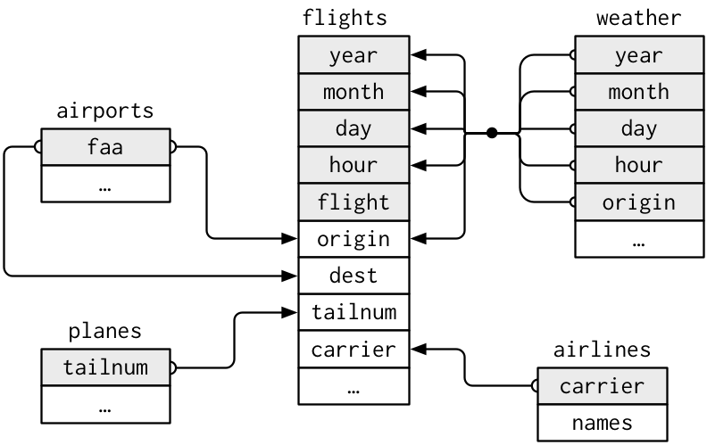

For the MIMIC-III data, the relation structure can be explored at https://mit-lcp.github.io/mimic-schema-spy/relationships.html.

### 9.1 Keys

- A **primary key** uniquely identifies an observation in its own table.
- A **foreign key** uniquely identifies an observation in another table.

## 10 Combine variables (columns)

### 10.1 Demo tables

**R**

```r
(x <- tribble(
  ~key, ~val_x,
  1, "x1",
  2, "x2",
  3, "x3"
))
```

```
# A tibble: 3 × 2
    key val_x
  <dbl> <chr>
1     1 x1
2     2 x2
3     3 x3
```

```r
(y <- tribble(
  ~key, ~val_y,
  1, "y1",
  2, "y2",
  4, "y3"
))
```

```
# A tibble: 3 × 2
    key val_y
  <dbl> <chr>
1     1 y1
2     2 y2
3     4 y3
```

**Python**

```python
x = pd.DataFrame({
  'key': [1, 2, 4],
  'val_x': ['x1', 'x2', 'x3']
})
x
```

```
   key val_x
0    1    x1
1    2    x2
2    4    x3
```

```python
y = pd.DataFrame({
  'key': [1, 2, 3],
  'val_y': ['y1', 'y2', 'y3']
})
x
```

```
   key val_x
0    1    x1
1    2    x2
2    4    x3
```

**Julia**

```julia
x = DataFrame(
  key = 1:3,
  val_x = ["x1", "x2", "x3"]
)
```

```
3×2 DataFrame
 Row │ key    val_x
     │ Int64  String
─────┼───────────────
   1 │     1  x1
   2 │     2  x2
   3 │     3  x3
```

```julia
y = DataFrame(
  key = [1, 2, 4],
  val_y = ["y1", "y2", "y3"]
)
```

```
3×2 DataFrame
 Row │ key    val_y
     │ Int64  String
─────┼───────────────
   1 │     1  y1
   2 │     2  y2
   3 │     4  y3
```

### 10.2 Inner join

- An **inner join** matches pairs of observations whenever their keys are equal:

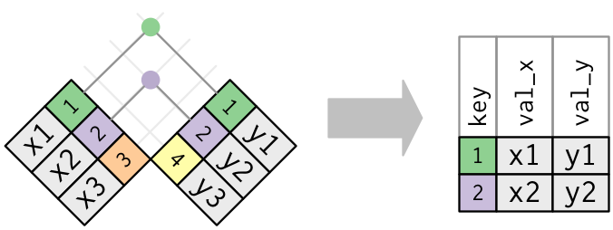

**R**

```r
inner_join(x, y, by = "key")
```

```
# A tibble: 2 × 3
    key val_x val_y
  <dbl> <chr> <chr>
1     1 x1    y1
2     2 x2    y2
```

Same as

```r
x |> inner_join(y, by = "key")
```

**Python**

```python
x.join(y.set_index('key'), on = 'key', how = 'inner')
```

```
   key val_x val_y
0    1    x1    y1
1    2    x2    y2
```

**Julia**

```julia
innerjoin(x, y, on = :key)
```

```
2×3 DataFrame
 Row │ key    val_x   val_y
     │ Int64  String  String
─────┼───────────────────────
   1 │     1  x1      y1
   2 │     2  x2      y2
```

### 10.3 Outer join

- An **outer join** keeps observations that appear in at least one of the tables.
- Three types of outer joins: left join, right join, and full join.
- A **left join** keeps all observations in `x`.

**R**

```r
left_join(x, y, by = "key")
```

```
# A tibble: 3 × 3
    key val_x val_y
  <dbl> <chr> <chr>
1     1 x1    y1
2     2 x2    y2
3     3 x3    <NA>
```

**Python**

```python
x.join(y.set_index('key'), on = 'key', how = 'left')
```

```
   key val_x val_y
0    1    x1    y1
1    2    x2    y2
2    4    x3   NaN
```

**Julia**

```julia
leftjoin(x, y, on = :key)
```

```
3×3 DataFrame
 Row │ key    val_x   val_y
     │ Int64  String  String?
─────┼────────────────────────
   1 │     1  x1      y1
   2 │     2  x2      y2
   3 │     3  x3      missing
```

- A **right join** keeps all observations in `y`.

**R**

```r
right_join(x, y, by = "key")
```

```
# A tibble: 3 × 3
    key val_x val_y
  <dbl> <chr> <chr>
1     1 x1    y1
2     2 x2    y2
3     4 <NA>  y3
```

**Python**

```python
x.join(y.set_index('key'), on = 'key', how = 'right')
```

```
     key val_x val_y
0.0    1    x1    y1
1.0    2    x2    y2
NaN    3   NaN    y3
```

**Julia**

```julia
rightjoin(x, y, on = :key)
```

```
3×3 DataFrame
 Row │ key    val_x    val_y
     │ Int64  String?  String
─────┼────────────────────────
   1 │     1  x1       y1
   2 │     2  x2       y2
   3 │     4  missing  y3
```

- A **full join** keeps all observations in `x` or `y`.

**R**

```r
full_join(x, y, by = "key")
```

```
# A tibble: 4 × 3
    key val_x val_y
  <dbl> <chr> <chr>
1     1 x1    y1
2     2 x2    y2
3     3 x3    <NA>
4     4 <NA>  y3
```

**Python**

```python
x.join(y.set_index('key'), on = 'key', how = 'outer')
```

```
     key val_x val_y
0.0    1    x1    y1
1.0    2    x2    y2
2.0    4    x3   NaN
NaN    3   NaN    y3
```

**Julia**

```julia
outerjoin(x, y, on = :key)
```

```
4×3 DataFrame
 Row │ key    val_x    val_y
     │ Int64  String?  String?
─────┼─────────────────────────
   1 │     1  x1       y1
   2 │     2  x2       y2
   3 │     3  x3       missing
   4 │     4  missing  y3
```

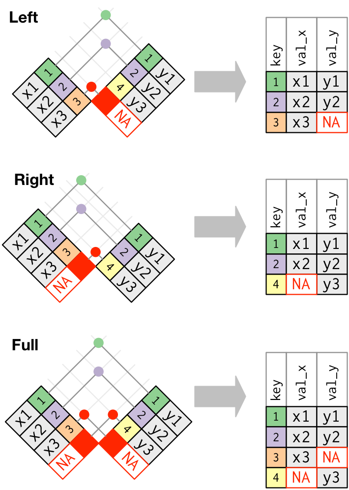

### 10.4 Duplicate keys

- One table has duplicate keys.

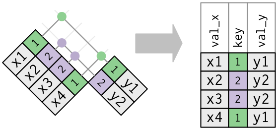

**R**

```r
x <- tribble(
  ~key, ~val_x,
  1, "x1",
  2, "x2",
  2, "x3",
  1, "x4"
)
x
```

```
# A tibble: 4 × 2
    key val_x
  <dbl> <chr>
1     1 x1
2     2 x2
3     2 x3
4     1 x4
```

```r
y <- tribble(
  ~key, ~val_y,
  1, "y1",
  2, "y2"
)
y
```

```
# A tibble: 2 × 2
    key val_y
  <dbl> <chr>
1     1 y1
2     2 y2
```

```r
left_join(x, y, by = "key")
```

```
# A tibble: 4 × 3
    key val_x val_y
  <dbl> <chr> <chr>
1     1 x1    y1
2     2 x2    y2
3     2 x3    y2
4     1 x4    y1
```

**Python**

```python
x = pd.DataFrame({
  'key': [1, 2, 2, 1],
  'val_x': ["x1", "x2", "x3", "x4"]
})
x
```

```
   key val_x
0    1    x1
1    2    x2
2    2    x3
3    1    x4
```

```python
y = pd.DataFrame({
  'key': [1, 2],
  'val_y': ["y1", "y2"]
})
y
```

```
   key val_y
0    1    y1
1    2    y2
```

```python
x.join(y.set_index('key'), on = 'key', how = 'left')
```

```
   key val_x val_y
0    1    x1    y1
1    2    x2    y2
2    2    x3    y2
3    1    x4    y1
```

**Julia**

```julia
x = DataFrame(
  key = [1, 2, 2, 1],
  val_x = ["x1", "x2", "x3", "x4"]
)
```

```
4×2 DataFrame
 Row │ key    val_x
     │ Int64  String
─────┼───────────────
   1 │     1  x1
   2 │     2  x2
   3 │     2  x3
   4 │     1  x4
```

```julia
y = DataFrame(
  key = [1, 2],
  val_y = ["y1", "y2"]
)
```

```
2×2 DataFrame
 Row │ key    val_y
     │ Int64  String
─────┼───────────────
   1 │     1  y1
   2 │     2  y2
```

```julia
leftjoin(x, y, on = :key)
```

```
4×3 DataFrame
 Row │ key    val_x   val_y
     │ Int64  String  String?
─────┼────────────────────────
   1 │     1  x1      y1
   2 │     2  x2      y2
   3 │     2  x3      y2
   4 │     1  x4      y1
```

- Both tables have duplicate keys. You get all possible combinations, the Cartesian product:

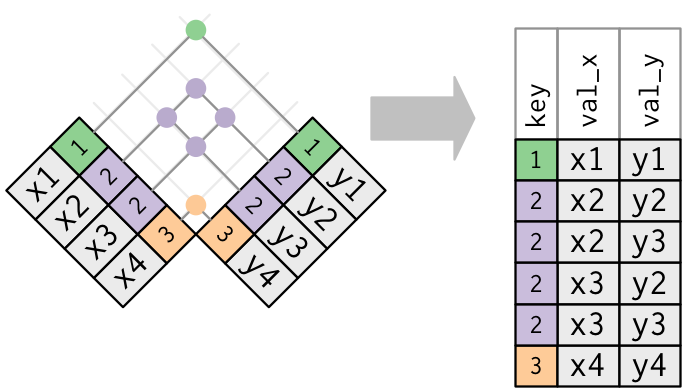

**R**

```r
x <- tribble(
  ~key, ~val_x,
  1, "x1",
  2, "x2",
  2, "x3",
  3, "x4"
)
y <- tribble(
  ~key, ~val_y,
  1, "y1",
  2, "y2",
  2, "y3",
  3, "y4"
)
left_join(x, y, by = "key")
```

```
# A tibble: 6 × 3
    key val_x val_y
  <dbl> <chr> <chr>
1     1 x1    y1
2     2 x2    y2
3     2 x2    y3
4     2 x3    y2
5     2 x3    y3
6     3 x4    y4
```

**Python**

```python
x = pd.DataFrame({
  'key': [1, 2, 2, 3],
  'val_x': ["x1", "x2", "x3", "x4"]
})
x
```

```
   key val_x
0    1    x1
1    2    x2
2    2    x3
3    3    x4
```

```python
y = pd.DataFrame({
  'key': [1, 2, 2, 3],
  'val_y': ["y1", "y2", "y3", "y4"]
})
y
```

```
   key val_y
0    1    y1
1    2    y2
2    2    y3
3    3    y4
```

```python
x.join(y.set_index('key'), on = 'key', how = 'left')
```

```
   key val_x val_y
0    1    x1    y1
1    2    x2    y2
1    2    x2    y3
2    2    x3    y2
2    2    x3    y3
3    3    x4    y4
```

**Julia**

```julia
x = DataFrame(
  key = [1, 2, 2, 3],
  val_x = ["x1", "x2", "x3", "x4"]
)
```

```
4×2 DataFrame
 Row │ key    val_x
     │ Int64  String
─────┼───────────────
   1 │     1  x1
   2 │     2  x2
   3 │     2  x3
   4 │     3  x4
```

```julia
y = DataFrame(
  key = [1, 2, 2, 3],
  val_y = ["y1", "y2", "y3", "y4"]
)
```

```
4×2 DataFrame
 Row │ key    val_y
     │ Int64  String
─────┼───────────────
   1 │     1  y1
   2 │     2  y2
   3 │     2  y3
   4 │     3  y4
```

```julia
leftjoin(x, y, on = :key)
```

```
6×3 DataFrame
 Row │ key    val_x   val_y
     │ Int64  String  String?
─────┼────────────────────────
   1 │     1  x1      y1
   2 │     2  x2      y2
   3 │     2  x3      y2
   4 │     2  x2      y3
   5 │     2  x3      y3
   6 │     3  x4      y4
```

- Let’s create a narrower table from the flights data:

**R**

```r
flights2 <- flights |>
  select(year:day, hour, origin, dest, tailnum, carrier) |>
  print(width = Inf)
```

```
# A tibble: 336,776 × 8
    year month   day  hour origin dest  tailnum carrier
   <int> <int> <int> <dbl> <chr>  <chr> <chr>   <chr>
 1  2013     1     1     5 EWR    IAH   N14228  UA
 2  2013     1     1     5 LGA    IAH   N24211  UA
 3  2013     1     1     5 JFK    MIA   N619AA  AA
 4  2013     1     1     5 JFK    BQN   N804JB  B6
 5  2013     1     1     6 LGA    ATL   N668DN  DL
 6  2013     1     1     5 EWR    ORD   N39463  UA
 7  2013     1     1     6 EWR    FLL   N516JB  B6
 8  2013     1     1     6 LGA    IAD   N829AS  EV
 9  2013     1     1     6 JFK    MCO   N593JB  B6
10  2013     1     1     6 LGA    ORD   N3ALAA  AA
# ℹ 336,766 more rows
```

**Python**

```python
flights2 = flights[['year', 'month', 'day', 'hour', 'origin', 'dest', 'tailnum', 'carrier']]
flights2
```

```
        year  month  day  hour origin dest tailnum carrier
0       2013      1    1     5    EWR  IAH  N14228      UA
1       2013      1    1     5    LGA  IAH  N24211      UA
2       2013      1    1     5    JFK  MIA  N619AA      AA
3       2013      1    1     5    JFK  BQN  N804JB      B6
4       2013      1    1     6    LGA  ATL  N668DN      DL
...      ...    ...  ...   ...    ...  ...     ...     ...
336771  2013      9   30    14    JFK  DCA     NaN      9E
336772  2013      9   30    22    LGA  SYR     NaN      9E
336773  2013      9   30    12    LGA  BNA  N535MQ      MQ
336774  2013      9   30    11    LGA  CLE  N511MQ      MQ
336775  2013      9   30     8    LGA  RDU  N839MQ      MQ

[336776 rows x 8 columns]
```

**Julia**

```julia
flights2 = select(
  flights,
  Between(:year, :day),
  :hour,
  :origin,
  :dest,
  :tailnum,
  :carrier
  )
```

```
336776×8 DataFrame
    Row │ year   month  day    hour     origin  dest    tailnum  carrier
        │ Int64  Int64  Int64  Float64  String  String  String?  String
────────┼────────────────────────────────────────────────────────────────
      1 │  2013      1      1      5.0  EWR     IAH     N14228   UA
      2 │  2013      1      1      5.0  LGA     IAH     N24211   UA
      3 │  2013      1      1      5.0  JFK     MIA     N619AA   AA
      4 │  2013      1      1      5.0  JFK     BQN     N804JB   B6
      5 │  2013      1      1      6.0  LGA     ATL     N668DN   DL
      6 │  2013      1      1      5.0  EWR     ORD     N39463   UA
      7 │  2013      1      1      6.0  EWR     FLL     N516JB   B6
      8 │  2013      1      1      6.0  LGA     IAD     N829AS   EV
   ⋮    │   ⋮      ⋮      ⋮       ⋮       ⋮       ⋮        ⋮        ⋮
 336770 │  2013      9     30     23.0  JFK     PSE     N516JB   B6
 336771 │  2013      9     30     18.0  LGA     BNA     N740EV   EV
 336772 │  2013      9     30     14.0  JFK     DCA     missing  9E
 336773 │  2013      9     30     22.0  LGA     SYR     missing  9E
 336774 │  2013      9     30     12.0  LGA     BNA     N535MQ   MQ
 336775 │  2013      9     30     11.0  LGA     CLE     N511MQ   MQ
 336776 │  2013      9     30      8.0  LGA     RDU     N839MQ   MQ
                                                      336761 rows omitted
```

- We want to merge with the `weather` table:

**R**

```r
weather
```

```
# A tibble: 26,115 × 15
   origin  year month   day  hour  temp  dewp humid wind_dir wind_speed
   <chr>  <int> <int> <int> <int> <dbl> <dbl> <dbl>    <dbl>      <dbl>
 1 EWR     2013     1     1     1  39.0  26.1  59.4      270      10.4
 2 EWR     2013     1     1     2  39.0  27.0  61.6      250       8.06
 3 EWR     2013     1     1     3  39.0  28.0  64.4      240      11.5
 4 EWR     2013     1     1     4  39.9  28.0  62.2      250      12.7
 5 EWR     2013     1     1     5  39.0  28.0  64.4      260      12.7
 6 EWR     2013     1     1     6  37.9  28.0  67.2      240      11.5
 7 EWR     2013     1     1     7  39.0  28.0  64.4      240      15.0
 8 EWR     2013     1     1     8  39.9  28.0  62.2      250      10.4
 9 EWR     2013     1     1     9  39.9  28.0  62.2      260      15.0
10 EWR     2013     1     1    10  41    28.0  59.6      260      13.8
# ℹ 26,105 more rows
# ℹ 5 more variables: wind_gust <dbl>, precip <dbl>, pressure <dbl>,
#   visib <dbl>, time_hour <dttm>
```

**Python**

```python
weather
```

```
      origin  year  month  day  hour   temp   dewp  humid  wind_dir  \
0        EWR  2013      1    1     1  39.02  26.06  59.37     270.0
1        EWR  2013      1    1     2  39.02  26.96  61.63     250.0
2        EWR  2013      1    1     3  39.02  28.04  64.43     240.0
3        EWR  2013      1    1     4  39.92  28.04  62.21     250.0
4        EWR  2013      1    1     5  39.02  28.04  64.43     260.0
...      ...   ...    ...  ...   ...    ...    ...    ...       ...
26110    LGA  2013     12   30    14  35.96  19.94  51.78     340.0
26111    LGA  2013     12   30    15  33.98  17.06  49.51     330.0
26112    LGA  2013     12   30    16  32.00  15.08  49.19     340.0
26113    LGA  2013     12   30    17  30.92  12.92  46.74     320.0
26114    LGA  2013     12   30    18  28.94  10.94  46.41     330.0

       wind_speed  wind_gust  precip  pressure  visib             time_hour
0        10.35702        NaN     0.0    1012.0   10.0  2013-01-01T06:00:00Z
1         8.05546        NaN     0.0    1012.3   10.0  2013-01-01T07:00:00Z
2        11.50780        NaN     0.0    1012.5   10.0  2013-01-01T08:00:00Z
3        12.65858        NaN     0.0    1012.2   10.0  2013-01-01T09:00:00Z
4        12.65858        NaN     0.0    1011.9   10.0  2013-01-01T10:00:00Z
...           ...        ...     ...       ...    ...                   ...
26110    13.80936   21.86482     0.0    1017.1   10.0  2013-12-30T19:00:00Z
26111    17.26170   21.86482     0.0    1018.8   10.0  2013-12-30T20:00:00Z
26112    14.96014   23.01560     0.0    1019.5   10.0  2013-12-30T21:00:00Z
26113    17.26170        NaN     0.0    1019.9   10.0  2013-12-30T22:00:00Z
26114    18.41248        NaN     0.0    1020.9   10.0  2013-12-30T23:00:00Z

[26115 rows x 15 columns]
```

**Julia**

```julia
weather
```

```
26115×15 DataFrame
   Row │ origin  year   month  day    hour   temp      dewp      humid     win ⋯
       │ String  Int64  Int64  Int64  Int64  Float64?  Float64?  Float64?  Flo ⋯
───────┼────────────────────────────────────────────────────────────────────────
     1 │ EWR      2013      1      1      1     39.02     26.06     59.37      ⋯
     2 │ EWR      2013      1      1      2     39.02     26.96     61.63
     3 │ EWR      2013      1      1      3     39.02     28.04     64.43
     4 │ EWR      2013      1      1      4     39.92     28.04     62.21
     5 │ EWR      2013      1      1      5     39.02     28.04     64.43      ⋯
     6 │ EWR      2013      1      1      6     37.94     28.04     67.21
     7 │ EWR      2013      1      1      7     39.02     28.04     64.43
     8 │ EWR      2013      1      1      8     39.92     28.04     62.21
   ⋮   │   ⋮       ⋮      ⋮      ⋮      ⋮       ⋮         ⋮         ⋮          ⋱
 26109 │ LGA      2013     12     30     12     37.94     23.0      54.51      ⋯
 26110 │ LGA      2013     12     30     13     37.04     21.92     53.97
 26111 │ LGA      2013     12     30     14     35.96     19.94     51.78
 26112 │ LGA      2013     12     30     15     33.98     17.06     49.51
 26113 │ LGA      2013     12     30     16     32.0      15.08     49.19      ⋯
 26114 │ LGA      2013     12     30     17     30.92     12.92     46.74
 26115 │ LGA      2013     12     30     18     28.94     10.94     46.41
                                                7 columns and 26100 rows omitted
```

### 10.5 Defining the key columns

**R**

- `by = NULL` (default): use all variables that appear in both tables:

```r
# same as: flights2 |> left_join(weather)
left_join(flights2, weather)
```

```
# A tibble: 336,776 × 18
    year month   day  hour origin dest  tailnum carrier  temp  dewp humid
   <int> <int> <int> <dbl> <chr>  <chr> <chr>   <chr>   <dbl> <dbl> <dbl>
 1  2013     1     1     5 EWR    IAH   N14228  UA       39.0  28.0  64.4
 2  2013     1     1     5 LGA    IAH   N24211  UA       39.9  25.0  54.8
 3  2013     1     1     5 JFK    MIA   N619AA  AA       39.0  27.0  61.6
 4  2013     1     1     5 JFK    BQN   N804JB  B6       39.0  27.0  61.6
 5  2013     1     1     6 LGA    ATL   N668DN  DL       39.9  25.0  54.8
 6  2013     1     1     5 EWR    ORD   N39463  UA       39.0  28.0  64.4
 7  2013     1     1     6 EWR    FLL   N516JB  B6       37.9  28.0  67.2
 8  2013     1     1     6 LGA    IAD   N829AS  EV       39.9  25.0  54.8
 9  2013     1     1     6 JFK    MCO   N593JB  B6       37.9  27.0  64.3
10  2013     1     1     6 LGA    ORD   N3ALAA  AA       39.9  25.0  54.8
# ℹ 336,766 more rows
# ℹ 7 more variables: wind_dir <dbl>, wind_speed <dbl>, wind_gust <dbl>,
#   precip <dbl>, pressure <dbl>, visib <dbl>, time_hour <dttm>
```

- `by = "x"`: use the common variable `x`:

```r
# same as: flights2 |> left_join(weather)
left_join(flights2, planes, by = "tailnum")
```

```
# A tibble: 336,776 × 16
   year.x month   day  hour origin dest  tailnum carrier year.y type
    <int> <int> <int> <dbl> <chr>  <chr> <chr>   <chr>    <int> <chr>
 1   2013     1     1     5 EWR    IAH   N14228  UA        1999 Fixed wing mult…
 2   2013     1     1     5 LGA    IAH   N24211  UA        1998 Fixed wing mult…
 3   2013     1     1     5 JFK    MIA   N619AA  AA        1990 Fixed wing mult…
 4   2013     1     1     5 JFK    BQN   N804JB  B6        2012 Fixed wing mult…
 5   2013     1     1     6 LGA    ATL   N668DN  DL        1991 Fixed wing mult…
 6   2013     1     1     5 EWR    ORD   N39463  UA        2012 Fixed wing mult…
 7   2013     1     1     6 EWR    FLL   N516JB  B6        2000 Fixed wing mult…
 8   2013     1     1     6 LGA    IAD   N829AS  EV        1998 Fixed wing mult…
 9   2013     1     1     6 JFK    MCO   N593JB  B6        2004 Fixed wing mult…
10   2013     1     1     6 LGA    ORD   N3ALAA  AA          NA <NA>
# ℹ 336,766 more rows
# ℹ 6 more variables: manufacturer <chr>, model <chr>, engines <int>,
#   seats <int>, speed <int>, engine <chr>
```

- `by = c("a" = "b")`: match variable `a` in table `x` to the variable `b` in table `y`.

```r
# same as: flights2 |> left_join(weather)
left_join(flights2, airports, by = c("dest" = "faa"))
```

```
# A tibble: 336,776 × 15
    year month   day  hour origin dest  tailnum carrier name     lat   lon   alt
   <int> <int> <int> <dbl> <chr>  <chr> <chr>   <chr>   <chr>  <dbl> <dbl> <dbl>
 1  2013     1     1     5 EWR    IAH   N14228  UA      Georg…  30.0 -95.3    97
 2  2013     1     1     5 LGA    IAH   N24211  UA      Georg…  30.0 -95.3    97
 3  2013     1     1     5 JFK    MIA   N619AA  AA      Miami…  25.8 -80.3     8
 4  2013     1     1     5 JFK    BQN   N804JB  B6      <NA>    NA    NA      NA
 5  2013     1     1     6 LGA    ATL   N668DN  DL      Harts…  33.6 -84.4  1026
 6  2013     1     1     5 EWR    ORD   N39463  UA      Chica…  42.0 -87.9   668
 7  2013     1     1     6 EWR    FLL   N516JB  B6      Fort …  26.1 -80.2     9
 8  2013     1     1     6 LGA    IAD   N829AS  EV      Washi…  38.9 -77.5   313
 9  2013     1     1     6 JFK    MCO   N593JB  B6      Orlan…  28.4 -81.3    96
10  2013     1     1     6 LGA    ORD   N3ALAA  AA      Chica…  42.0 -87.9   668
# ℹ 336,766 more rows
# ℹ 3 more variables: tz <dbl>, dst <chr>, tzone <chr>
```

**Python**

- Match multiple keys using multi-index:

```python
keys = ['origin', 'year', 'month', 'day', 'hour']
flights2.join(
  weather.set_index(keys),
  on = keys,
  how = 'left')
```

```
        year  month  day  hour origin dest tailnum carrier   temp   dewp  \
0       2013      1    1     5    EWR  IAH  N14228      UA  39.02  28.04
1       2013      1    1     5    LGA  IAH  N24211      UA  39.92  24.98
2       2013      1    1     5    JFK  MIA  N619AA      AA  39.02  26.96
3       2013      1    1     5    JFK  BQN  N804JB      B6  39.02  26.96
4       2013      1    1     6    LGA  ATL  N668DN      DL  39.92  24.98
...      ...    ...  ...   ...    ...  ...     ...     ...    ...    ...
336771  2013      9   30    14    JFK  DCA     NaN      9E  68.00  55.04
336772  2013      9   30    22    LGA  SYR     NaN      9E  64.94  53.06
336773  2013      9   30    12    LGA  BNA  N535MQ      MQ  69.08  48.02
336774  2013      9   30    11    LGA  CLE  N511MQ      MQ  66.92  48.92
336775  2013      9   30     8    LGA  RDU  N839MQ      MQ  60.98  51.08

        humid  wind_dir  wind_speed  wind_gust  precip  pressure  visib  \
0       64.43     260.0    12.65858        NaN     0.0    1011.9   10.0
```

[output cut: 25 more lines]

- Match the common variable `tailnum`:

```python
flights2.join(
  planes.set_index('tailnum'),
  on = 'tailnum',
  how = 'left',
  lsuffix = '_x',
  rsuffix = '_y'
  )
```

```
        year_x  month  day  hour origin dest tailnum carrier  year_y  \
0         2013      1    1     5    EWR  IAH  N14228      UA  1999.0
1         2013      1    1     5    LGA  IAH  N24211      UA  1998.0
2         2013      1    1     5    JFK  MIA  N619AA      AA  1990.0
3         2013      1    1     5    JFK  BQN  N804JB      B6  2012.0
4         2013      1    1     6    LGA  ATL  N668DN      DL  1991.0
...        ...    ...  ...   ...    ...  ...     ...     ...     ...
336771    2013      9   30    14    JFK  DCA     NaN      9E     NaN
336772    2013      9   30    22    LGA  SYR     NaN      9E     NaN
336773    2013      9   30    12    LGA  BNA  N535MQ      MQ     NaN
336774    2013      9   30    11    LGA  CLE  N511MQ      MQ     NaN
336775    2013      9   30     8    LGA  RDU  N839MQ      MQ     NaN

                           type manufacturer     model  engines  seats  speed  \
0       Fixed wing multi engine       BOEING   737-824      2.0  149.0    NaN
```

[output cut: 25 more lines]

- Match variable `a` in table `x` to the variable `b` in table `y`.

```python
flights2.set_index(
  'dest'
  ).join(
    airports.set_index('faa'),
    how = 'left'
    )
```

```
      year  month  day  hour origin tailnum carrier  \
dest
ABQ   2013     10    1    20    JFK  N554JB      B6
ABQ   2013     10    2    20    JFK  N607JB      B6
ABQ   2013     10    3    20    JFK  N591JB      B6
ABQ   2013     10    4    20    JFK  N662JB      B6
ABQ   2013     10    5    19    JFK  N580JB      B6
...    ...    ...  ...   ...    ...     ...     ...
XNA   2013      9   29    17    LGA  N725MQ      MQ
XNA   2013      9   30     7    LGA  N735MQ      MQ
XNA   2013      9   30     8    EWR  N14117      EV
XNA   2013      9   30    15    LGA  N725MQ      MQ
XNA   2013      9   30    17    LGA  N720MQ      MQ

                                   name        lat         lon     alt   tz  \
dest
ABQ   Albuquerque International Sunport  35.040222 -106.609194  5355.0 -7.0
ABQ   Albuquerque International Sunport  35.040222 -106.609194  5355.0 -7.0
ABQ   Albuquerque International Sunport  35.040222 -106.609194  5355.0 -7.0
ABQ   Albuquerque International Sunport  35.040222 -106.609194  5355.0 -7.0
ABQ   Albuquerque International Sunport  35.040222 -106.609194  5355.0 -7.0
...                                 ...        ...         ...     ...  ...
XNA                NW Arkansas Regional  36.281869  -94.306811  1287.0 -6.0
XNA                NW Arkansas Regional  36.281869  -94.306811  1287.0 -6.0
XNA                NW Arkansas Regional  36.281869  -94.306811  1287.0 -6.0
XNA                NW Arkansas Regional  36.281869  -94.306811  1287.0 -6.0
XNA                NW Arkansas Regional  36.281869  -94.306811  1287.0 -6.0

     dst            tzone
dest
ABQ    A   America/Denver
ABQ    A   America/Denver
ABQ    A   America/Denver
ABQ    A   America/Denver
ABQ    A   America/Denver
...   ..              ...
XNA    A  America/Chicago
XNA    A  America/Chicago
XNA    A  America/Chicago
XNA    A  America/Chicago
XNA    A  America/Chicago

[336776 rows x 14 columns]
```

**Julia**

- Match multiple variables:

```julia
leftjoin(
  flights2,
  weather,
  on = [:year, :month, :day, :hour, :origin]
  )
```

```
336776×18 DataFrame
    Row │ year   month  day    hour     origin  dest    tailnum  carrier  temp ⋯
        │ Int64  Int64  Int64  Float64  String  String  String?  String   Floa ⋯
────────┼───────────────────────────────────────────────────────────────────────
      1 │  2013      1      1      5.0  EWR     IAH     N14228   UA            ⋯
      2 │  2013      1      1      5.0  LGA     IAH     N24211   UA
      3 │  2013      1      1      5.0  JFK     MIA     N619AA   AA
      4 │  2013      1      1      5.0  JFK     BQN     N804JB   B6
      5 │  2013      1      1      6.0  LGA     ATL     N668DN   DL            ⋯
      6 │  2013      1      1      5.0  EWR     ORD     N39463   UA
      7 │  2013      1      1      6.0  EWR     FLL     N516JB   B6
      8 │  2013      1      1      6.0  LGA     IAD     N829AS   EV
   ⋮    │   ⋮      ⋮      ⋮       ⋮       ⋮       ⋮        ⋮        ⋮          ⋱
 336770 │  2013      9      2     16.0  EWR     CVG     N14573   EV       miss ⋯
 336771 │  2013      9      2     16.0  EWR     SAV     N11547   EV       miss
 336772 │  2013      9      2     16.0  EWR     ROC     N11548   EV       miss
 336773 │  2013      9      2     16.0  EWR     GSO     N13978   EV       miss
 336774 │  2013      9      2     16.0  EWR     ATL     N13202   EV       miss ⋯
 336775 │  2013      9      2     16.0  EWR     CVG     missing  9E       miss
 336776 │  2013      9      2     16.0  EWR     PHX     missing  US       miss
                                              10 columns and 336761 rows omitted
```

- Match the common variable `tailnum`:

```julia
leftjoin(
  flights2,
  planes,
  on = :tailnum,
  makeunique = true,
  matchmissing = :notequal
  )
```

```
336776×16 DataFrame
    Row │ year   month  day    hour     origin  dest    tailnum  carrier  year ⋯
        │ Int64  Int64  Int64  Float64  String  String  String?  String   Int6 ⋯
────────┼───────────────────────────────────────────────────────────────────────
      1 │  2013      1      1      5.0  EWR     IAH     N14228   UA          1 ⋯
      2 │  2013      1      1      5.0  LGA     IAH     N24211   UA          1
      3 │  2013      1      1      5.0  JFK     MIA     N619AA   AA          1
      4 │  2013      1      1      5.0  JFK     BQN     N804JB   B6          2
      5 │  2013      1      1      6.0  LGA     ATL     N668DN   DL          1 ⋯
      6 │  2013      1      1      5.0  EWR     ORD     N39463   UA          2
      7 │  2013      1      1      6.0  EWR     FLL     N516JB   B6          2
      8 │  2013      1      1      6.0  LGA     IAD     N829AS   EV          1
   ⋮    │   ⋮      ⋮      ⋮       ⋮       ⋮       ⋮        ⋮        ⋮        ⋮ ⋱
 336770 │  2013      9     30     21.0  JFK     DCA     N807MQ   MQ       miss ⋯
 336771 │  2013      9     30     21.0  LGA     BNA     N532MQ   MQ       miss
 336772 │  2013      9     30     14.0  JFK     DCA     missing  9E       miss
 336773 │  2013      9     30     22.0  LGA     SYR     missing  9E       miss
 336774 │  2013      9     30     12.0  LGA     BNA     N535MQ   MQ       miss ⋯
 336775 │  2013      9     30     11.0  LGA     CLE     N511MQ   MQ       miss
 336776 │  2013      9     30      8.0  LGA     RDU     N839MQ   MQ       miss
                                               8 columns and 336761 rows omitted
```

- Match variable `a` in table `x` to the variable `b` in table `y`.

```julia
leftjoin(
  flights2,
  airports,
  on = :dest => :faa
  )
```

```
336776×15 DataFrame
    Row │ year   month  day    hour     origin  dest    tailnum  carrier  name ⋯
        │ Int64  Int64  Int64  Float64  String  String  String?  String   Stri ⋯
────────┼───────────────────────────────────────────────────────────────────────
      1 │  2013      1      1      5.0  EWR     IAH     N14228   UA       Geor ⋯
      2 │  2013      1      1      5.0  LGA     IAH     N24211   UA       Geor
      3 │  2013      1      1      5.0  JFK     MIA     N619AA   AA       Miam
      4 │  2013      1      1      6.0  LGA     ATL     N668DN   DL       Hart
      5 │  2013      1      1      5.0  EWR     ORD     N39463   UA       Chic ⋯
      6 │  2013      1      1      6.0  EWR     FLL     N516JB   B6       Fort
      7 │  2013      1      1      6.0  LGA     IAD     N829AS   EV       Wash
      8 │  2013      1      1      6.0  JFK     MCO     N593JB   B6       Orla
   ⋮    │   ⋮      ⋮      ⋮       ⋮       ⋮       ⋮        ⋮        ⋮          ⋱
 336770 │  2013      9     30      8.0  JFK     SJU     N3772H   DL       miss ⋯
 336771 │  2013      9     30     14.0  JFK     SJU     N652JB   B6       miss
 336772 │  2013      9     30     15.0  JFK     SJU     N5FTAA   AA       miss
 336773 │  2013      9     30     15.0  JFK     SJU     N3756    DL       miss
 336774 │  2013      9     30     20.0  JFK     SJU     N396DA   DL       miss ⋯
 336775 │  2013      9     30     21.0  JFK     SJU     N633JB   B6       miss
 336776 │  2013      9     30     23.0  JFK     PSE     N516JB   B6       miss
                                               7 columns and 336761 rows omitted
```

## 11 Combine cases (rows)

- Top 10 most popular destinations:

**R**

```r
top_dest <- flights |>
  count(dest, sort = TRUE) |>
  head(10) |>
  print()
```

```
# A tibble: 10 × 2
   dest      n
   <chr> <int>
 1 ORD   17283
 2 ATL   17215
 3 LAX   16174
 4 BOS   15508
 5 MCO   14082
 6 CLT   14064
 7 SFO   13331
 8 FLL   12055
 9 MIA   11728
10 DCA    9705
```

**Python**

```python
top_dest = flights.groupby('dest')['dest'].count(
  ).to_frame(
    name = 'n'
    ).reset_index(
      ).sort_values(
        'n',
        ascending = False
        ).head(10)
top_dest
```

```
   dest      n
69  ORD  17283
4   ATL  17215
49  LAX  16174
11  BOS  15508
54  MCO  14082
23  CLT  14064
90  SFO  13331
35  FLL  12055
58  MIA  11728
28  DCA   9705
```

**Julia**

```julia
top_dest = @pipe flights |>
  groupby(_, :dest) |>
  combine(_, nrow) |>
  sort(_, :nrow, rev = true) |>
  first(_, 10)
```

```
10×2 DataFrame
 Row │ dest    nrow
     │ String  Int64
─────┼───────────────
   1 │ ORD     17283
   2 │ ATL     17215
   3 │ LAX     16174
   4 │ BOS     15508
   5 │ MCO     14082
   6 │ CLT     14064
   7 │ SFO     13331
   8 │ FLL     12055
   9 │ MIA     11728
  10 │ DCA      9705
```

- How to filter the cases that fly to these destinations?

### 11.1 Semi-join

- `semi_join(x, y)` keeps the rows in `x` that have a match in `y`.

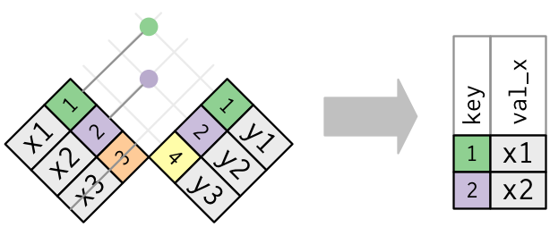

**R**

```r
semi_join(flights, top_dest)
```

```
# A tibble: 141,145 × 19
    year month   day dep_time sched_dep_time dep_delay arr_time sched_arr_time
   <int> <int> <int>    <int>          <int>     <dbl>    <int>          <int>
 1  2013     1     1      542            540         2      923            850
 2  2013     1     1      554            600        -6      812            837
 3  2013     1     1      554            558        -4      740            728
 4  2013     1     1      555            600        -5      913            854
 5  2013     1     1      557            600        -3      838            846
 6  2013     1     1      558            600        -2      753            745
 7  2013     1     1      558            600        -2      924            917
 8  2013     1     1      558            600        -2      923            937
 9  2013     1     1      559            559         0      702            706
10  2013     1     1      600            600         0      851            858
# ℹ 141,135 more rows
# ℹ 11 more variables: arr_delay <dbl>, carrier <chr>, flight <int>,
#   tailnum <chr>, origin <chr>, dest <chr>, air_time <dbl>, distance <dbl>,
#   hour <dbl>, minute <dbl>, time_hour <dttm>
```

**Python**

```python
flights.loc[flights['dest'].isin(top_dest['dest'])]
```

```
        year  month  day  dep_time  sched_dep_time  dep_delay  arr_time  \
2       2013      1    1     542.0             540        2.0     923.0
4       2013      1    1     554.0             600       -6.0     812.0
5       2013      1    1     554.0             558       -4.0     740.0
6       2013      1    1     555.0             600       -5.0     913.0
8       2013      1    1     557.0             600       -3.0     838.0
...      ...    ...  ...       ...             ...        ...       ...
336755  2013      9   30    2149.0            2156       -7.0    2245.0
336762  2013      9   30    2233.0            2113       80.0     112.0
336763  2013      9   30    2235.0            2001      154.0      59.0
336768  2013      9   30    2307.0            2255       12.0    2359.0
336771  2013      9   30       NaN            1455        NaN       NaN

        sched_arr_time  arr_delay carrier  flight tailnum origin dest  \
2                  850       33.0      AA    1141  N619AA    JFK  MIA
```

[output cut: 25 more lines]

**Julia**

```julia
semijoin(flights, top_dest, on = :dest)
```

```
141145×19 DataFrame
    Row │ year   month  day    dep_time  sched_dep_time  dep_delay  arr_time   ⋯
        │ Int64  Int64  Int64  Int64?    Int64           Float64?   Int64?     ⋯
────────┼───────────────────────────────────────────────────────────────────────
      1 │  2013      1      1       542             540        2.0       923   ⋯
      2 │  2013      1      1       554             600       -6.0       812
      3 │  2013      1      1       554             558       -4.0       740
      4 │  2013      1      1       555             600       -5.0       913
      5 │  2013      1      1       557             600       -3.0       838   ⋯
      6 │  2013      1      1       558             600       -2.0       753
      7 │  2013      1      1       558             600       -2.0       924
      8 │  2013      1      1       558             600       -2.0       923
   ⋮    │   ⋮      ⋮      ⋮       ⋮            ⋮             ⋮         ⋮       ⋱
 141139 │  2013      9     30      2140            2140        0.0        10   ⋯
 141140 │  2013      9     30      2147            2137       10.0        30
 141141 │  2013      9     30      2149            2156       -7.0      2245
 141142 │  2013      9     30      2233            2113       80.0       112
 141143 │  2013      9     30      2235            2001      154.0        59   ⋯
 141144 │  2013      9     30      2307            2255       12.0      2359
 141145 │  2013      9     30   missing            1455  missing     missing
                                              12 columns and 141130 rows omitted
```

### 11.2 Anti-join

- `anti_join(x, y)` keeps the rows that don’t have a match.

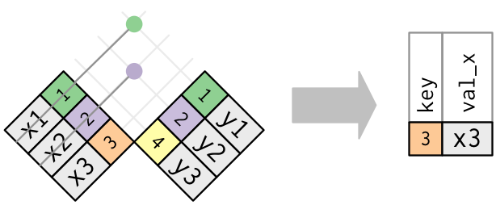

- Useful to see what will not be joined.

**R**

```r
# Planes that are not in planes table
flights |>
  anti_join(planes, by = "tailnum") |>
  count(tailnum, sort = TRUE)
```

```
# A tibble: 722 × 2
   tailnum     n
   <chr>   <int>
 1 <NA>     2512
 2 N725MQ    575
 3 N722MQ    513
 4 N723MQ    507
 5 N713MQ    483
 6 N735MQ    396
 7 N0EGMQ    371
 8 N534MQ    364
 9 N542MQ    363
10 N531MQ    349
# ℹ 712 more rows
```

**Python**

```python
flights.loc[-flights['tailnum'].isin(planes['tailnum'])].groupby('tailnum')['tailnum'].count().sort_values(ascending = False)
```

```
tailnum
N725MQ    575
N722MQ    513
N723MQ    507
N713MQ    483
N735MQ    396
         ...
N7ASAA      1
N3LFAA      1
N7ALAA      1
N7AEAA      1
N5ERAA      1
Name: tailnum, Length: 721, dtype: int64
```

**Julia**

```julia
@pipe antijoin(
  flights,
  planes,
  on = :tailnum,
  matchmissing = :notequal
  ) |>
  groupby(_, :tailnum) |>
  combine(_, nrow) |>
  sort(_, :nrow, rev = true)
```

```
722×2 DataFrame
 Row │ tailnum  nrow
     │ String?  Int64
─────┼────────────────
   1 │ missing   2512
   2 │ N725MQ     575
   3 │ N722MQ     513
   4 │ N723MQ     507
   5 │ N713MQ     483
   6 │ N735MQ     396
   7 │ N0EGMQ     371
   8 │ N534MQ     364
  ⋮  │    ⋮       ⋮
 716 │ N502SW       1
 717 │ N451UW       1
 718 │ N7BKAA       1
 719 │ N7CAAA       1
 720 │ N5FCAA       1
 721 │ N5ERAA       1
 722 │ N647MQ       1
      707 rows omitted
```

## 12 Set operations

- Generate two tables:

**R**

```r
(df1 <- tribble(
  ~x, ~y,
  1,  1,
  2,  1
))
```

```
# A tibble: 2 × 2
      x     y
  <dbl> <dbl>
1     1     1
2     2     1
```

```r
(df2 <- tribble(
  ~x, ~y,
  1,  1,
  1,  2
))
```

```
# A tibble: 2 × 2
      x     y
  <dbl> <dbl>
1     1     1
2     1     2
```

**Python**

```python
df1 = pd.DataFrame({
  'x': [1, 2],
  'y': [1, 1]
})
df1
```

```
   x  y
0  1  1
1  2  1
```

```python
df2 = pd.DataFrame({
  'x': [1, 1],
  'y': [1, 2]
})
df2
```

```
   x  y
0  1  1
1  1  2
```

**Julia**

```julia
df1 = DataFrame(
  x = [1, 2],
  y = [1, 1]
)
```

```
2×2 DataFrame
 Row │ x      y
     │ Int64  Int64
─────┼──────────────
   1 │     1      1
   2 │     2      1
```

```julia
df2 = DataFrame(
  x = [1, 1],
  y = [1, 2]
)
```

```
2×2 DataFrame
 Row │ x      y
     │ Int64  Int64
─────┼──────────────
   1 │     1      1
   2 │     1      2
```

- `bind_rows(x, y)` stacks table `x` one on top of `y`.

**R**

```r
bind_rows(df1, df2)
```

```
# A tibble: 4 × 2
      x     y
  <dbl> <dbl>
1     1     1
2     2     1
3     1     1
4     1     2
```

**Python**

```python
pd.concat([df1, df2], axis = 0)
```

```
   x  y
0  1  1
1  2  1
0  1  1
1  1  2
```

**Julia**

```julia
vcat(df1, df2)
```

```
4×2 DataFrame
 Row │ x      y
     │ Int64  Int64
─────┼──────────────
   1 │     1      1
   2 │     2      1
   3 │     1      1
   4 │     1      2
```

- `intersect(x, y)` returns rows that appear in both `x` and `y`.

**R**

```r
intersect(df1, df2)
```

```
# A tibble: 1 × 2
      x     y
  <dbl> <dbl>
1     1     1
```

**Python**

```python
pd.merge(df1, df2, how = 'inner', on = ['x', 'y'])
```

```
   x  y
0  1  1
```

**Julia**

```julia
DataFrame(intersect(eachrow(df1), eachrow(df2)))
```

```
1×2 DataFrame
 Row │ x      y
     │ Int64  Int64
─────┼──────────────
   1 │     1      1
```

- `union(x, y)` returns unique observations in `x` and `y`.

**R**

```r
union(df1, df2)
```

```
# A tibble: 3 × 2
      x     y
  <dbl> <dbl>
1     1     1
2     2     1
3     1     2
```

**Python**

```python
pd.merge(df1, df2, how = 'outer', on = ['x', 'y'])
```

```
   x  y
0  1  1
1  2  1
2  1  2
```

**Julia**

```julia
DataFrame(union(eachrow(df1), eachrow(df2)))
```

```
3×2 DataFrame
 Row │ x      y
     │ Int64  Int64
─────┼──────────────
   1 │     1      1
   2 │     2      1
   3 │     1      2
```

- `setdiff(x, y)` returns rows that appear in `x` but not in `y`.

**R**

```r
setdiff(df1, df2)
```

```
# A tibble: 1 × 2
      x     y
  <dbl> <dbl>
1     2     1
```

```r
setdiff(df2, df1)
```

```
# A tibble: 1 × 2
      x     y
  <dbl> <dbl>
1     1     2
```

**Python (???)**

Not sure how to do this elegantly.

**Julia**

```julia
DataFrame(setdiff(eachrow(df1), eachrow(df2)))
```

```
1×2 DataFrame
 Row │ x      y
     │ Int64  Int64
─────┼──────────────
   1 │     2      1
```

```julia
DataFrame(setdiff(eachrow(df2), eachrow(df1)))
```

```
1×2 DataFrame
 Row │ x      y
     │ Int64  Int64
─────┼──────────────
   1 │     1      2
```

## 13 Cheat sheet

[Posit dplyr cheat sheet](https://rstudio.github.io/cheatsheets/html/data-transformation.html) is extremely helpful.